# Supervised Learning - Foundations: ReCell

#### Analysis of Release Year vs Selfie Camera

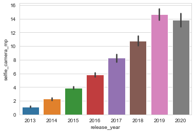

```python
sns.barplot(data = df, x= 'release_year', y='selfie_camera_mp')
plt.show()
```

**Obversations**

- On average the selfie camera has increase each year except from 2019 to 2020

#### Analysis of Screen Size vs New Price

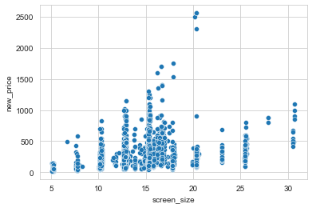

```python
sns.scatterplot(data = df, x = 'screen_size', y = 'new_price')
plt.show()
```

**Observations**

- There is a positive correlation between Screen Size and New Price
- There are a handful of devices that have large screens, but are cheaper than smaller devices

#### Analysis of 5G vs Price

```python
df.groupby('5g')['new_price'].agg(['count','mean'])
```

| 5g | count | mean |
| --- | --- | --- |
| no | 3302 | 220.179 |
| yes | 152 | 603.288 |

**Observations**

- Most devices in the data set are not 5G
- The devices which are 5G have an average price of almost 3X higher than non 5G devices

#### Analysis of Release Year vs Screen Size

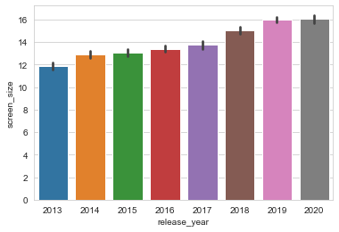

```python
sns.barplot(data = df, x= 'release_year', y='screen_size')
plt.show()
```

**Observations**

- Screen size has increase each year
- 2019 and 2020 are very close together in average screen size

#### Analysis of Main Camera vs Selfie Camera

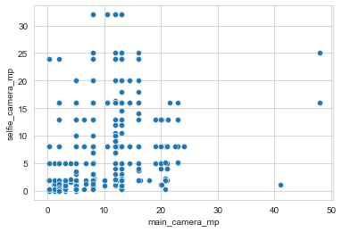

```python
sns.scatterplot(data=df, x='main_camera_mp', y='selfie_camera_mp')
plt.show()
```

**Observations**

- There is a positive correlation between main camera and selfie camera
- There are some devices which have large main cameras but small selfie camera and vice versa

## Data Preprocessing

- Missing value treatment
- Feature engineering (if needed)
- Outlier detection and treatment (if needed)
- Preparing data for modeling
- Any other preprocessing steps (if needed)

### Feature Engineering

```python
# Create new column for used price divided by new price
df['used_new_price_%'] = df['used_price'] / df['new_price']
df.head()
```

|  | brand_name | os | screen_size | 4g | 5g | main_camera_mp | selfie_camera_mp | int_memory | ram | battery | weight | release_year | days_used | new_price | used_price | used_price_log | price_category | used_new_price_% |
| --- | --- | --- | --- | --- | --- | --- | --- | --- | --- | --- | --- | --- | --- | --- | --- | --- | --- | --- |
| 0 | Honor | Android | 14.500 | yes | no | 13.000 | 5.000 | 64.000 | 3.000 | 3020.000 | 146.000 | 2020 | 127 | 111.620 | 74.260 | 4.308 | Budget | 0.665 |
| 1 | Honor | Android | 17.300 | yes | yes | 13.000 | 16.000 | 128.000 | 8.000 | 4300.000 | 213.000 | 2020 | 325 | 249.390 | 174.530 | 5.162 | Mid | 0.700 |
| 2 | Honor | Android | 16.690 | yes | yes | 13.000 | 8.000 | 128.000 | 8.000 | 4200.000 | 213.000 | 2020 | 162 | 359.470 | 165.850 | 5.111 | Mid | 0.461 |
| 3 | Honor | Android | 25.500 | yes | yes | 13.000 | 8.000 | 64.000 | 6.000 | 7250.000 | 480.000 | 2020 | 345 | 278.930 | 169.930 | 5.135 | Mid | 0.609 |
| 4 | Honor | Android | 15.320 | yes | no | 13.000 | 8.000 | 64.000 | 3.000 | 5000.000 | 185.000 | 2020 | 293 | 140.870 | 80.640 | 4.390 | Budget | 0.572 |

### EDA

- It is a good idea to explore the data once again after manipulating it.

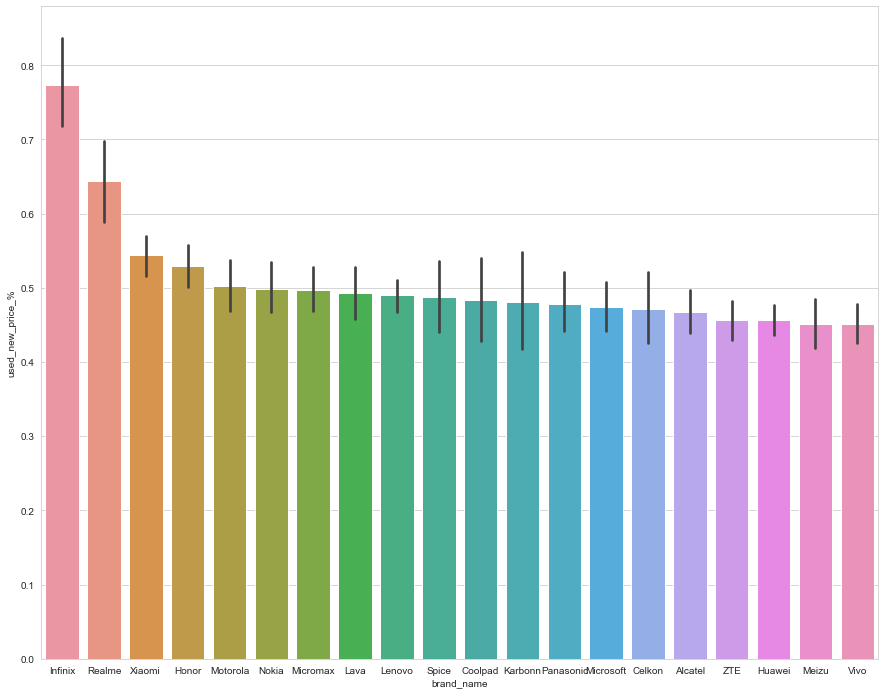

```python
plt.figure(figsize=(15,12))
sns.barplot(data=df, x='brand_name', y='used_new_price_%', order=df.groupby(['brand_name'])['used_new_price_%'].mean().sort_values(ascending=False).iloc[:20].index)
plt.show()
```

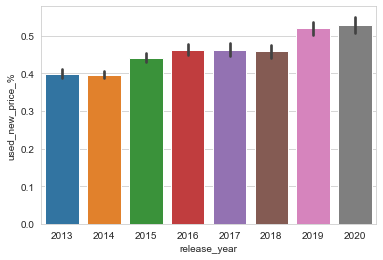

```python
sns.barplot(data=df, x='release_year', y='used_new_price_%')
plt.show()
```

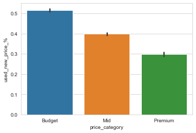

```python
sns.barplot(data=df, x='price_category', y='used_new_price_%')
plt.show()
```

```python
pd.crosstab(df['price_category'], df['release_year'], normalize='index')
```

| release_year price_category | 2013 | 2014 | 2015 | 2016 | 2017 | 2018 | 2019 | 2020 |
| --- | --- | --- | --- | --- | --- | --- | --- | --- |
| Budget | 0.211 | 0.210 | 0.162 | 0.112 | 0.076 | 0.064 | 0.100 | 0.064 |
| Mid | 0.136 | 0.182 | 0.160 | 0.120 | 0.098 | 0.106 | 0.130 | 0.069 |
| Premium | 0.043 | 0.090 | 0.064 | 0.083 | 0.100 | 0.185 | 0.254 | 0.182 |

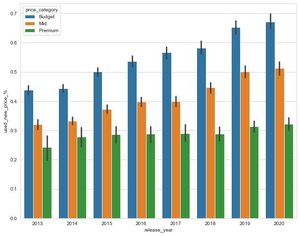

```python
plt.figure(figsize=(10,8))
sns.barplot(data = df, x='release_year', y='used_new_price_%', hue='price_category')
plt.show()
```

**Observations**

- The phones which have the highest price percentage between Used to New is Infinix, Realme and Xiaomi
- Newer phones hold their value better than older ones for used price which is what we would expect
- Budget phones hold their value better than Mid and Premium phones
- Year over Year budget phones hold their value more than mid and premium phones

### Missing Value Treatment

```python
df1 = df.copy()
```

```python
df1.isnull().sum()
```

```
brand_name            0
os                    0
screen_size           0
4g                    0
5g                    0
main_camera_mp      179
selfie_camera_mp      2
int_memory            4
ram                   4
battery               6
weight                7
release_year          0
days_used             0
new_price             0
used_price            0
used_price_log        0
price_category        0
used_new_price_%      0
dtype: int64
```

```python
# Fill in N/A values with the median
null_columns = ['main_camera_mp', 'selfie_camera_mp', 'int_memory', 'ram', 'battery', 'weight']

for column in null_columns:
    df1[column] = df1.groupby('brand_name')[column].transform(lambda x: x.fillna(x.median()))
```

```python
df1.isnull().sum()
```

```
brand_name           0
os                   0
screen_size          0
4g                   0
5g                   0
main_camera_mp      10
selfie_camera_mp     0
int_memory           0
ram                  0
battery              0
weight               0
release_year         0
days_used            0
new_price            0
used_price           0
used_price_log       0
price_category       0
used_new_price_%     0
dtype: int64
```

```python
# Fill in the remaining N/A values for main_camera_mp
df1['main_camera_mp'] = df1['main_camera_mp'].fillna(df1['main_camera_mp'].median())

df1.isnull().sum()
```

```
brand_name          0
os                  0
screen_size         0
4g                  0
5g                  0
main_camera_mp      0
selfie_camera_mp    0
int_memory          0
ram                 0
battery             0
weight              0
release_year        0
days_used           0
new_price           0
used_price          0
used_price_log      0
price_category      0
used_new_price_%    0
dtype: int64
```

```python
df.describe(include='all').T
```

|  | count | unique | top | freq | mean | std | min | 25% | 50% | 75% | max |
| --- | --- | --- | --- | --- | --- | --- | --- | --- | --- | --- | --- |
| brand_name | 3454 | 34 | Others | 502 | NaN | NaN | NaN | NaN | NaN | NaN | NaN |
| os | 3454 | 4 | Android | 3214 | NaN | NaN | NaN | NaN | NaN | NaN | NaN |
| screen_size | 3454.000 | NaN | NaN | NaN | 13.713 | 3.805 | 5.080 | 12.700 | 12.830 | 15.340 | 30.710 |
| 4g | 3454 | 2 | yes | 2335 | NaN | NaN | NaN | NaN | NaN | NaN | NaN |
| 5g | 3454 | 2 | no | 3302 | NaN | NaN | NaN | NaN | NaN | NaN | NaN |
| main_camera_mp | 3275.000 | NaN | NaN | NaN | 9.460 | 4.815 | 0.080 | 5.000 | 8.000 | 13.000 | 48.000 |
| selfie_camera_mp | 3452.000 | NaN | NaN | NaN | 6.554 | 6.970 | 0.000 | 2.000 | 5.000 | 8.000 | 32.000 |
| int_memory | 3450.000 | NaN | NaN | NaN | 54.573 | 84.972 | 0.010 | 16.000 | 32.000 | 64.000 | 1024.000 |
| ram | 3450.000 | NaN | NaN | NaN | 4.036 | 1.365 | 0.020 | 4.000 | 4.000 | 4.000 | 12.000 |
| battery | 3448.000 | NaN | NaN | NaN | 3133.403 | 1299.683 | 500.000 | 2100.000 | 3000.000 | 4000.000 | 9720.000 |
| weight | 3447.000 | NaN | NaN | NaN | 182.752 | 88.413 | 69.000 | 142.000 | 160.000 | 185.000 | 855.000 |
| release_year | 3454.000 | NaN | NaN | NaN | 2015.965 | 2.298 | 2013.000 | 2014.000 | 2015.500 | 2018.000 | 2020.000 |
| days_used | 3454.000 | NaN | NaN | NaN | 674.870 | 248.580 | 91.000 | 533.500 | 690.500 | 868.750 | 1094.000 |
| new_price | 3454.000 | NaN | NaN | NaN | 237.039 | 194.303 | 18.200 | 120.343 | 189.785 | 291.115 | 2560.200 |
| used_price | 3454.000 | NaN | NaN | NaN | 92.303 | 54.702 | 4.650 | 56.483 | 81.870 | 116.245 | 749.520 |
| used_price_log | 3454.000 | NaN | NaN | NaN | 4.365 | 0.589 | 1.537 | 4.034 | 4.405 | 4.756 | 6.619 |
| price_category | 3454 | 3 | Budget | 1844 | NaN | NaN | NaN | NaN | NaN | NaN | NaN |
| used_new_price_% | 3454.000 | NaN | NaN | NaN | 0.449 | 0.161 | 0.088 | 0.336 | 0.429 | 0.545 | 0.984 |

### Outlier Detection

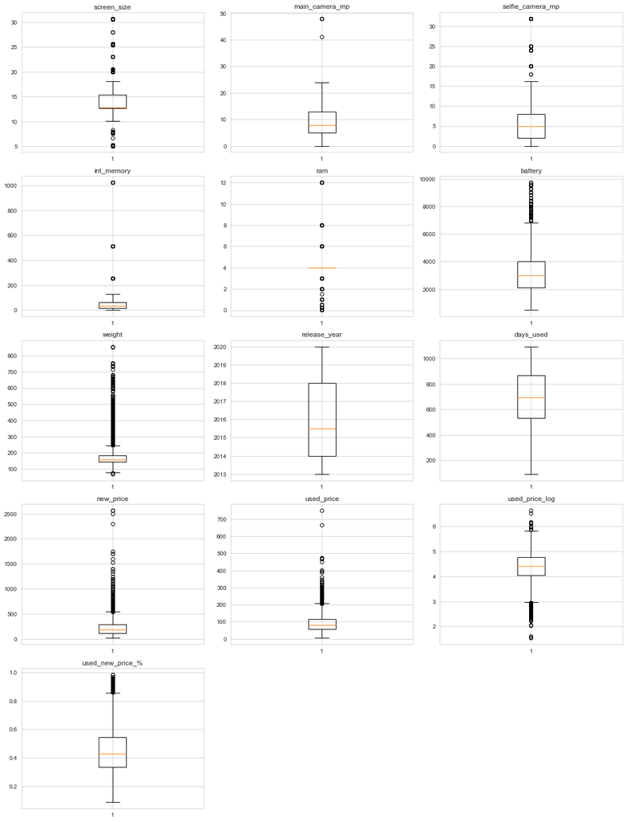

```python
numeric_columns = df1.select_dtypes(include=np.number).columns.tolist()

plt.figure(figsize=(15, 35))

for i, variable in enumerate(numeric_columns):
    plt.subplot(9, 3, i + 1)
    plt.boxplot(df1[variable], whis=1.5)
    plt.tight_layout()
    plt.title(variable)

plt.show()
```

## Building a Linear Regression model

```python
# We have to convert anything that is an object into a dummy variable
df1.dtypes
```

```
brand_name            object
os                    object
screen_size          float64
4g                    object
5g                    object
main_camera_mp       float64
selfie_camera_mp     float64
int_memory           float64
ram                  float64
battery              float64
weight               float64
release_year           int64
days_used              int64
new_price            float64
used_price           float64
used_price_log       float64
price_category      category
used_new_price_%     float64
dtype: object
```

```python
df1 = pd.get_dummies(df1, columns = ['brand_name','os','4g','5g','price_category'], drop_first=True)
df1.columns
```

```
Index(['screen_size', 'main_camera_mp', 'selfie_camera_mp', 'int_memory',
       'ram', 'battery', 'weight', 'release_year', 'days_used', 'new_price',
       'used_price', 'used_price_log', 'used_new_price_%',
       'brand_name_Alcatel', 'brand_name_Apple', 'brand_name_Asus',
       'brand_name_BlackBerry', 'brand_name_Celkon', 'brand_name_Coolpad',
       'brand_name_Gionee', 'brand_name_Google', 'brand_name_HTC',
       'brand_name_Honor', 'brand_name_Huawei', 'brand_name_Infinix',
       'brand_name_Karbonn', 'brand_name_LG', 'brand_name_Lava',
       'brand_name_Lenovo', 'brand_name_Meizu', 'brand_name_Micromax',
       'brand_name_Microsoft', 'brand_name_Motorola', 'brand_name_Nokia',
       'brand_name_OnePlus', 'brand_name_Oppo', 'brand_name_Others',
       'brand_name_Panasonic', 'brand_name_Realme', 'brand_name_Samsung',
       'brand_name_Sony', 'brand_name_Spice', 'brand_name_Vivo',
       'brand_name_XOLO', 'brand_name_Xiaomi', 'brand_name_ZTE', 'os_Others',
       'os_Windows', 'os_iOS', '4g_yes', '5g_yes', 'price_category_Mid',
       'price_category_Premium'],
      dtype='object')
```

```python
# Drop price columns and prices which we are trying to predict
# Use used_price_log as dependent variable instead of used_price because used_price_log has the data as more normal

x = df1.drop(['used_price', 'used_price_log', 'new_price', 'used_new_price_%'], axis=1)
y = df1['used_price_log']
```

```python
# Split data into train and test data
x_train, x_test, y_train, y_test = train_test_split(x, y, test_size=0.30, random_state=1)
```

```python
x_train.shape
```

```
(2417, 49)
```

```python
x_test.shape
```

```
(1037, 49)
```

## Checking Linear Regression Assumptions

- In order to make statistical inferences from a linear regression model, it is important to ensure that the assumptions of linear regression are satisfied.

**Assumptions for Linear Regression Model:**

- No Multicollinearity
- Linearity of variables
- Independence of error terms
- Normality of error terms
- No Heteroscedasticity

```python
# Add constants

x_train1 = sm.add_constant(x_train)
x_test1 = sm.add_constant(x_test)

olsmod = sm.OLS(y_train, x_train1)
olsres = olsmod.fit()
print(olsres.summary())
```

```
                            OLS Regression Results
==============================================================================
Dep. Variable:         used_price_log   R-squared:                       0.791
Model:                            OLS   Adj. R-squared:                  0.787
Method:                 Least Squares   F-statistic:                     183.2
Date:                Fri, 04 Mar 2022   Prob (F-statistic):               0.00
Time:                        13:53:11   Log-Likelihood:                -234.62
No. Observations:                2417   AIC:                             569.2
Df Residuals:                    2367   BIC:                             858.8
Df Model:                          49
Covariance Type:            nonrobust
==========================================================================================
                             coef    std err          t      P>|t|      [0.025      0.975]
------------------------------------------------------------------------------------------
const                      6.7274     10.638      0.632      0.527     -14.133      27.588
screen_size                0.0373      0.004      9.472      0.000       0.030       0.045
main_camera_mp             0.0321      0.002     18.973      0.000       0.029       0.035
selfie_camera_mp           0.0174      0.001     13.259      0.000       0.015       0.020
int_memory                 0.0004   8.12e-05      4.910      0.000       0.000       0.001
ram                        0.0521      0.006      8.898      0.000       0.041       0.064
battery                 -7.68e-06   8.45e-06     -0.909      0.364   -2.43e-05    8.89e-06
weight                     0.0009      0.000      5.953      0.000       0.001       0.001
release_year              -0.0019      0.005     -0.364      0.716      -0.012       0.008
days_used               3.078e-05   3.58e-05      0.860      0.390   -3.94e-05       0.000
brand_name_Alcatel        -0.0183      0.055     -0.332      0.740      -0.127       0.090
brand_name_Apple           0.3109      0.170      1.826      0.068      -0.023       0.645
brand_name_Asus            0.0309      0.056      0.556      0.578      -0.078       0.140
brand_name_BlackBerry      0.0831      0.081      1.021      0.307      -0.076       0.243
brand_name_Celkon         -0.2068      0.077     -2.698      0.007      -0.357      -0.056
brand_name_Coolpad        -0.0327      0.085     -0.386      0.699      -0.198       0.133
brand_name_Gionee          0.0682      0.067      1.018      0.309      -0.063       0.200
brand_name_Google          0.0918      0.098      0.935      0.350      -0.101       0.284
brand_name_HTC             0.0247      0.056      0.442      0.659      -0.085       0.134
brand_name_Honor          -0.0002      0.057     -0.003      0.997      -0.112       0.112
brand_name_Huawei          0.0127      0.052      0.245      0.806      -0.089       0.114
brand_name_Infinix         0.0803      0.108      0.743      0.458      -0.132       0.292
brand_name_Karbonn        -0.0048      0.078     -0.061      0.951      -0.157       0.148
brand_name_LG              0.0273      0.053      0.520      0.603      -0.076       0.130
brand_name_Lava           -0.0402      0.072     -0.556      0.578      -0.182       0.102
brand_name_Lenovo          0.0261      0.052      0.497      0.620      -0.077       0.129
```

[output cut: 20 more lines]

```
4g_yes                     0.1180      0.018      6.455      0.000       0.082       0.154
5g_yes                    -0.0310      0.037     -0.845      0.398      -0.103       0.041
price_category_Mid         0.1874      0.015     12.400      0.000       0.158       0.217
price_category_Premium     0.3950      0.023     16.911      0.000       0.349       0.441
==============================================================================
Omnibus:                      242.776   Durbin-Watson:                   1.930
Prob(Omnibus):                  0.000   Jarque-Bera (JB):              934.958
Skew:                          -0.441   Prob(JB):                    9.47e-204
Kurtosis:                       5.917   Cond. No.                     7.67e+06
==============================================================================

Warnings:
[1] Standard Errors assume that the covariance matrix of the errors is correctly specified.
[2] The condition number is large, 7.67e+06. This might indicate that there are
strong multicollinearity or other numerical problems.
```

#### Test for Multicollinearity

- **General Rule of Thumb**:
  - If VIF is 1, then there is no correlation among the $k$th predictor and the remaining predictor variables, and hence, the variance of $\beta_k$ is not inflated at all.
  - If VIF exceeds 5, we say there is moderate VIF, and if it is 10 or exceeding 10, it shows signs of high multi-collinearity.
  - The purpose of the analysis should dictate which threshold to use.

```python
# Check VIF of the predictors
# Add option to display scientific notation as full number with 3 decimal places
pd.options.display.float_format = '{:.3f}'.format
from statsmodels.stats.outliers_influence import variance_inflation_factor

vif_series1 = pd.Series(
    [variance_inflation_factor(x_train1.values, i) for i in range(x_train1.shape[1])],
    index=x_train1.columns,
)

vif_series1
```

```
const                    3767535.060
screen_size                    7.607
main_camera_mp                 2.153
selfie_camera_mp               2.848
int_memory                     1.372
ram                            2.176
battery                        4.093
weight                         6.447
release_year                   4.881
days_used                      2.660
brand_name_Alcatel             3.406
brand_name_Apple              12.997
brand_name_Asus                3.332
brand_name_BlackBerry          1.628
brand_name_Celkon              1.763
brand_name_Coolpad             1.468
brand_name_Gionee              1.952
brand_name_Google              1.321
brand_name_HTC                 3.412
brand_name_Honor               3.340
brand_name_Huawei              5.983
brand_name_Infinix             1.284
brand_name_Karbonn             1.571
brand_name_LG                  4.845
brand_name_Lava                1.710
brand_name_Lenovo              4.563
brand_name_Meizu               2.180
brand_name_Micromax            3.343
brand_name_Microsoft           1.869
brand_name_Motorola            3.274
brand_name_Nokia               3.469
brand_name_OnePlus             1.442
brand_name_Oppo                3.978
brand_name_Others              9.712
brand_name_Panasonic           2.110
brand_name_Realme              1.941
brand_name_Samsung             7.540
brand_name_Sony                2.942
brand_name_Spice               1.682
brand_name_Vivo                3.656
brand_name_XOLO                2.144
brand_name_Xiaomi              3.718
brand_name_ZTE                 3.798
os_Others                      1.828
os_Windows                     1.596
os_iOS                        11.800
4g_yes                         2.433
5g_yes                         1.826
price_category_Mid             1.708
price_category_Premium         1.930
dtype: float64
```

```python
# Drop brand_name_apple which has the highest VIF besides the constant
# R-squared and Adjusted R-squared have no difference
x_train2 = x_train1.drop(["brand_name_Apple"], axis=1)
olsmod_1 = sm.OLS(y_train, x_train2)
olsres_1 = olsmod_1.fit()
print(
    "R-squared:",
    np.round(olsres_1.rsquared, 3),
    "\nAdjusted R-squared:",
    np.round(olsres_1.rsquared_adj, 3),
)
```

```
R-squared: 0.791
Adjusted R-squared: 0.787
```

```python
# Check VIF again
from statsmodels.stats.outliers_influence import variance_inflation_factor

vif_series2 = pd.Series(
    [variance_inflation_factor(x_train2.values, i) for i in range(x_train2.shape[1])],
    index=x_train2.columns,
)

vif_series2
```

```
const                    3765744.181
screen_size                    7.562
main_camera_mp                 2.149
selfie_camera_mp               2.833
int_memory                     1.372
ram                            2.164
battery                        4.090
weight                         6.444
release_year                   4.879
days_used                      2.660
brand_name_Alcatel             3.227
brand_name_Asus                3.147
brand_name_BlackBerry          1.559
brand_name_Celkon              1.717
brand_name_Coolpad             1.435
brand_name_Gionee              1.887
brand_name_Google              1.294
brand_name_HTC                 3.246
brand_name_Honor               3.155
brand_name_Huawei              5.582
brand_name_Infinix             1.264
brand_name_Karbonn             1.540
brand_name_LG                  4.566
brand_name_Lava                1.667
brand_name_Lenovo              4.289
brand_name_Meizu               2.092
brand_name_Micromax            3.184
brand_name_Microsoft           1.834
brand_name_Motorola            3.105
brand_name_Nokia               3.258
brand_name_OnePlus             1.408
brand_name_Oppo                3.769
brand_name_Others              9.072
brand_name_Panasonic           2.033
brand_name_Realme              1.870
brand_name_Samsung             7.001
brand_name_Sony                2.799
brand_name_Spice               1.646
brand_name_Vivo                3.450
brand_name_XOLO                2.073
brand_name_Xiaomi              3.505
brand_name_ZTE                 3.599
os_Others                      1.718
os_Windows                     1.594
os_iOS                         1.911
4g_yes                         2.430
5g_yes                         1.818
price_category_Mid             1.708
price_category_Premium         1.928
dtype: float64
```

```python
# Try removing brand_name_others since it's almost 10 VIF

x_train3 = x_train2.drop(["brand_name_Others"], axis=1)
olsmod_2 = sm.OLS(y_train, x_train3)
olsres_2 = olsmod_1.fit()
print(
    "R-squared:",
    np.round(olsres_2.rsquared, 3),
    "\nAdjusted R-squared:",
    np.round(olsres_2.rsquared_adj, 3),
)
```

```
R-squared: 0.791
Adjusted R-squared: 0.787
```

```python
# No change in R-squared and adjusted R-squared

from statsmodels.stats.outliers_influence import variance_inflation_factor

vif_series3 = pd.Series(
    [variance_inflation_factor(x_train3.values, i) for i in range(x_train3.shape[1])],
    index=x_train3.columns,
)

vif_series3
```

```
const                    3765301.809
screen_size                    7.485
main_camera_mp                 2.148
selfie_camera_mp               2.832
int_memory                     1.371
ram                            2.160
battery                        4.089
weight                         6.418
release_year                   4.878
days_used                      2.659
brand_name_Alcatel             1.217
brand_name_Asus                1.201
brand_name_BlackBerry          1.121
brand_name_Celkon              1.163
brand_name_Coolpad             1.053
brand_name_Gionee              1.091
brand_name_Google              1.043
brand_name_HTC                 1.223
brand_name_Honor               1.281
brand_name_Huawei              1.502
brand_name_Infinix             1.062
brand_name_Karbonn             1.071
brand_name_LG                  1.340
brand_name_Lava                1.069
brand_name_Lenovo              1.302
brand_name_Meizu               1.135
brand_name_Micromax            1.207
brand_name_Microsoft           1.494
brand_name_Motorola            1.257
brand_name_Nokia               1.481
brand_name_OnePlus             1.084
brand_name_Oppo                1.376
brand_name_Panasonic           1.111
brand_name_Realme              1.162
brand_name_Samsung             1.573
brand_name_Sony                1.211
brand_name_Spice               1.074
brand_name_Vivo                1.327
brand_name_XOLO                1.124
brand_name_Xiaomi              1.312
brand_name_ZTE                 1.262
os_Others                      1.707
os_Windows                     1.593
os_iOS                         1.171
4g_yes                         2.426
5g_yes                         1.817
price_category_Mid             1.708
price_category_Premium         1.928
dtype: float64
```

**Observations**

- No variables are above or close to 10 VIF
- We have satisfied Multicollinearity and can move on to next step

#### Linearity of Variables

- Check P-Values of each variable

```python
olsmod_2 = sm.OLS(y_train, x_train3)
olsres_2 = olsmod_2.fit()
print(olsres_2.summary())
```

```
                            OLS Regression Results
==============================================================================
Dep. Variable:         used_price_log   R-squared:                       0.791
Model:                            OLS   Adj. R-squared:                  0.787
Method:                 Least Squares   F-statistic:                     190.7
Date:                Fri, 04 Mar 2022   Prob (F-statistic):               0.00
Time:                        13:53:30   Log-Likelihood:                -236.61
No. Observations:                2417   AIC:                             569.2
Df Residuals:                    2369   BIC:                             847.2
Df Model:                          47
Covariance Type:            nonrobust
==========================================================================================
                             coef    std err          t      P>|t|      [0.025      0.975]
------------------------------------------------------------------------------------------
const                      6.3901     10.639      0.601      0.548     -14.472      27.253
screen_size                0.0381      0.004      9.761      0.000       0.030       0.046
main_camera_mp             0.0322      0.002     19.046      0.000       0.029       0.036
selfie_camera_mp           0.0172      0.001     13.143      0.000       0.015       0.020
int_memory                 0.0004   8.12e-05      4.919      0.000       0.000       0.001
ram                        0.0531      0.006      9.097      0.000       0.042       0.065
battery                -7.195e-06   8.45e-06     -0.851      0.395   -2.38e-05    9.38e-06
weight                     0.0009      0.000      5.878      0.000       0.001       0.001
release_year              -0.0018      0.005     -0.334      0.738      -0.012       0.009
days_used               3.006e-05   3.58e-05      0.839      0.401   -4.02e-05       0.000
brand_name_Alcatel        -0.0097      0.033     -0.294      0.769      -0.074       0.055
brand_name_Asus            0.0387      0.033      1.160      0.246      -0.027       0.104
brand_name_BlackBerry      0.0841      0.068      1.246      0.213      -0.048       0.216
brand_name_Celkon         -0.1974      0.062     -3.171      0.002      -0.319      -0.075
brand_name_Coolpad        -0.0233      0.072     -0.326      0.745      -0.164       0.117
brand_name_Gionee          0.0780      0.050      1.557      0.120      -0.020       0.176
brand_name_Google          0.0982      0.087      1.125      0.260      -0.073       0.269
brand_name_HTC             0.0344      0.033      1.027      0.304      -0.031       0.100
brand_name_Honor           0.0073      0.035      0.206      0.837      -0.062       0.077
brand_name_Huawei          0.0201      0.026      0.779      0.436      -0.031       0.071
brand_name_Infinix         0.0881      0.098      0.896      0.371      -0.105       0.281
brand_name_Karbonn         0.0069      0.064      0.107      0.915      -0.119       0.133
brand_name_LG              0.0363      0.028      1.315      0.189      -0.018       0.091
brand_name_Lava           -0.0291      0.057     -0.509      0.611      -0.141       0.083
brand_name_Lenovo          0.0344      0.028      1.226      0.220      -0.021       0.089
brand_name_Meizu          -0.0341      0.047     -0.727      0.467      -0.126       0.058
```

[output cut: 18 more lines]

```
4g_yes                     0.1185      0.018      6.491      0.000       0.083       0.154
5g_yes                    -0.0358      0.037     -0.978      0.328      -0.108       0.036
price_category_Mid         0.1874      0.015     12.394      0.000       0.158       0.217
price_category_Premium     0.3963      0.023     16.964      0.000       0.350       0.442
==============================================================================
Omnibus:                      244.236   Durbin-Watson:                   1.929
Prob(Omnibus):                  0.000   Jarque-Bera (JB):              930.091
Skew:                          -0.448   Prob(JB):                    1.08e-202
Kurtosis:                       5.904   Cond. No.                     7.67e+06
==============================================================================

Warnings:
[1] Standard Errors assume that the covariance matrix of the errors is correctly specified.
[2] The condition number is large, 7.67e+06. This might indicate that there are
strong multicollinearity or other numerical problems.
```

**Observations**

- brand_name_Karbonn has a p-value of .9, we will remove this and re-run the regression

```python
x_train4 = x_train3.drop(["brand_name_Karbonn"], axis=1)
olsmod_3 = sm.OLS(y_train, x_train4)
olsres_3 = olsmod_3.fit()
print(olsres_3.summary())
```

```
                            OLS Regression Results
==============================================================================
Dep. Variable:         used_price_log   R-squared:                       0.791
Model:                            OLS   Adj. R-squared:                  0.787
Method:                 Least Squares   F-statistic:                     195.0
Date:                Fri, 04 Mar 2022   Prob (F-statistic):               0.00
Time:                        13:53:33   Log-Likelihood:                -236.62
No. Observations:                2417   AIC:                             567.2
Df Residuals:                    2370   BIC:                             839.4
Df Model:                          46
Covariance Type:            nonrobust
==========================================================================================
                             coef    std err          t      P>|t|      [0.025      0.975]
------------------------------------------------------------------------------------------
const                      6.4704     10.610      0.610      0.542     -14.336      27.276
screen_size                0.0381      0.004      9.788      0.000       0.030       0.046
main_camera_mp             0.0322      0.002     19.065      0.000       0.029       0.036
selfie_camera_mp           0.0172      0.001     13.152      0.000       0.015       0.020
int_memory                 0.0004   8.11e-05      4.930      0.000       0.000       0.001
ram                        0.0531      0.006      9.100      0.000       0.042       0.064
battery                -7.229e-06   8.44e-06     -0.856      0.392   -2.38e-05    9.33e-06
weight                     0.0009      0.000      5.880      0.000       0.001       0.001
release_year              -0.0018      0.005     -0.343      0.732      -0.012       0.009
days_used               2.995e-05   3.58e-05      0.837      0.403   -4.02e-05       0.000
brand_name_Alcatel        -0.0100      0.033     -0.305      0.760      -0.074       0.054
brand_name_Asus            0.0384      0.033      1.155      0.248      -0.027       0.104
brand_name_BlackBerry      0.0839      0.067      1.244      0.214      -0.048       0.216
brand_name_Celkon         -0.1979      0.062     -3.189      0.001      -0.320      -0.076
brand_name_Coolpad        -0.0236      0.072     -0.330      0.742      -0.164       0.117
brand_name_Gionee          0.0777      0.050      1.554      0.120      -0.020       0.176
brand_name_Google          0.0980      0.087      1.124      0.261      -0.073       0.269
brand_name_HTC             0.0341      0.033      1.022      0.307      -0.031       0.100
brand_name_Honor           0.0070      0.035      0.198      0.843      -0.062       0.076
brand_name_Huawei          0.0199      0.026      0.772      0.440      -0.031       0.070
brand_name_Infinix         0.0879      0.098      0.894      0.371      -0.105       0.281
brand_name_LG              0.0361      0.028      1.311      0.190      -0.018       0.090
brand_name_Lava           -0.0295      0.057     -0.517      0.605      -0.141       0.082
brand_name_Lenovo          0.0341      0.028      1.221      0.222      -0.021       0.089
brand_name_Meizu          -0.0344      0.047     -0.734      0.463      -0.126       0.058
brand_name_Micromax       -0.1470      0.033     -4.444      0.000      -0.212      -0.082
```

[output cut: 17 more lines]

```
4g_yes                     0.1184      0.018      6.496      0.000       0.083       0.154
5g_yes                    -0.0357      0.037     -0.976      0.329      -0.107       0.036
price_category_Mid         0.1873      0.015     12.409      0.000       0.158       0.217
price_category_Premium     0.3962      0.023     16.972      0.000       0.350       0.442
==============================================================================
Omnibus:                      244.269   Durbin-Watson:                   1.929
Prob(Omnibus):                  0.000   Jarque-Bera (JB):              930.573
Skew:                          -0.448   Prob(JB):                    8.48e-203
Kurtosis:                       5.905   Cond. No.                     7.65e+06
==============================================================================

Warnings:
[1] Standard Errors assume that the covariance matrix of the errors is correctly specified.
[2] The condition number is large, 7.65e+06. This might indicate that there are
strong multicollinearity or other numerical problems.
```

**Observations**

- No change in R-squarred or adjusted R-squarred
- We will remove this field and try removing the next highest which is brand_Name_XOLO

```python
x_train5 = x_train4.drop(["brand_name_XOLO"], axis=1)
olsmod_4 = sm.OLS(y_train, x_train5)
olsres_4 = olsmod_4.fit()
print(olsres_4.summary())
```

```
                            OLS Regression Results
==============================================================================
Dep. Variable:         used_price_log   R-squared:                       0.791
Model:                            OLS   Adj. R-squared:                  0.787
Method:                 Least Squares   F-statistic:                     199.4
Date:                Fri, 04 Mar 2022   Prob (F-statistic):               0.00
Time:                        13:53:36   Log-Likelihood:                -236.62
No. Observations:                2417   AIC:                             565.2
Df Residuals:                    2371   BIC:                             831.6
Df Model:                          45
Covariance Type:            nonrobust
==========================================================================================
                             coef    std err          t      P>|t|      [0.025      0.975]
------------------------------------------------------------------------------------------
const                      6.5348     10.595      0.617      0.537     -14.242      27.311
screen_size                0.0382      0.004      9.811      0.000       0.031       0.046
main_camera_mp             0.0322      0.002     19.083      0.000       0.029       0.036
selfie_camera_mp           0.0172      0.001     13.156      0.000       0.015       0.020
int_memory                 0.0004    8.1e-05      4.930      0.000       0.000       0.001
ram                        0.0531      0.006      9.108      0.000       0.042       0.065
battery                -7.204e-06   8.44e-06     -0.854      0.393   -2.38e-05    9.34e-06
weight                     0.0009      0.000      5.892      0.000       0.001       0.001
release_year              -0.0018      0.005     -0.349      0.727      -0.012       0.008
days_used               2.993e-05   3.58e-05      0.836      0.403   -4.02e-05       0.000
brand_name_Alcatel        -0.0105      0.033     -0.323      0.747      -0.074       0.053
brand_name_Asus            0.0380      0.033      1.149      0.251      -0.027       0.103
brand_name_BlackBerry      0.0836      0.067      1.240      0.215      -0.049       0.216
brand_name_Celkon         -0.1984      0.062     -3.205      0.001      -0.320      -0.077
brand_name_Coolpad        -0.0240      0.071     -0.336      0.737      -0.164       0.116
brand_name_Gionee          0.0772      0.050      1.549      0.121      -0.021       0.175
brand_name_Google          0.0977      0.087      1.121      0.263      -0.073       0.269
brand_name_HTC             0.0337      0.033      1.015      0.310      -0.031       0.099
brand_name_Honor           0.0065      0.035      0.187      0.852      -0.062       0.075
brand_name_Huawei          0.0194      0.026      0.763      0.446      -0.031       0.069
brand_name_Infinix         0.0875      0.098      0.890      0.373      -0.105       0.280
brand_name_LG              0.0356      0.027      1.306      0.192      -0.018       0.089
brand_name_Lava           -0.0301      0.057     -0.530      0.596      -0.142       0.081
brand_name_Lenovo          0.0336      0.028      1.216      0.224      -0.021       0.088
brand_name_Meizu          -0.0348      0.047     -0.745      0.456      -0.126       0.057
brand_name_Micromax       -0.1476      0.033     -4.505      0.000      -0.212      -0.083
```

[output cut: 16 more lines]

```
4g_yes                     0.1182      0.018      6.508      0.000       0.083       0.154
5g_yes                    -0.0357      0.037     -0.975      0.330      -0.107       0.036
price_category_Mid         0.1872      0.015     12.439      0.000       0.158       0.217
price_category_Premium     0.3961      0.023     16.982      0.000       0.350       0.442
==============================================================================
Omnibus:                      244.501   Durbin-Watson:                   1.929
Prob(Omnibus):                  0.000   Jarque-Bera (JB):              931.473
Skew:                          -0.448   Prob(JB):                    5.41e-203
Kurtosis:                       5.906   Cond. No.                     7.64e+06
==============================================================================

Warnings:
[1] Standard Errors assume that the covariance matrix of the errors is correctly specified.
[2] The condition number is large, 7.64e+06. This might indicate that there are
strong multicollinearity or other numerical problems.
```

**Observations**

- No change in R-squarred or adjusted R-squarred
- We will remove this field and try removing the next highest which is os_Windows

```python
x_train6 = x_train5.drop(["os_Windows"], axis=1)
olsmod_5 = sm.OLS(y_train, x_train6)
olsres_5 = olsmod_5.fit()
print(olsres_5.summary())
```

```
                            OLS Regression Results
==============================================================================
Dep. Variable:         used_price_log   R-squared:                       0.791
Model:                            OLS   Adj. R-squared:                  0.787
Method:                 Least Squares   F-statistic:                     204.0
Date:                Fri, 04 Mar 2022   Prob (F-statistic):               0.00
Time:                        13:53:40   Log-Likelihood:                -236.63
No. Observations:                2417   AIC:                             563.3
Df Residuals:                    2372   BIC:                             823.8
Df Model:                          44
Covariance Type:            nonrobust
==========================================================================================
                             coef    std err          t      P>|t|      [0.025      0.975]
------------------------------------------------------------------------------------------
const                      6.4335     10.567      0.609      0.543     -14.287      27.154
screen_size                0.0382      0.004      9.813      0.000       0.031       0.046
main_camera_mp             0.0322      0.002     19.086      0.000       0.029       0.036
selfie_camera_mp           0.0172      0.001     13.160      0.000       0.015       0.020
int_memory                 0.0004    8.1e-05      4.929      0.000       0.000       0.001
ram                        0.0530      0.006      9.124      0.000       0.042       0.064
battery                 -7.17e-06   8.43e-06     -0.850      0.395   -2.37e-05    9.37e-06
weight                     0.0009      0.000      5.893      0.000       0.001       0.001
release_year              -0.0018      0.005     -0.341      0.733      -0.012       0.008
days_used               3.002e-05   3.58e-05      0.839      0.401   -4.01e-05       0.000
brand_name_Alcatel        -0.0104      0.033     -0.320      0.749      -0.074       0.054
brand_name_Asus            0.0381      0.033      1.154      0.249      -0.027       0.103
brand_name_BlackBerry      0.0834      0.067      1.238      0.216      -0.049       0.216
brand_name_Celkon         -0.1984      0.062     -3.205      0.001      -0.320      -0.077
brand_name_Coolpad        -0.0240      0.071     -0.335      0.737      -0.164       0.116
brand_name_Gionee          0.0773      0.050      1.553      0.121      -0.020       0.175
brand_name_Google          0.0977      0.087      1.121      0.262      -0.073       0.269
brand_name_HTC             0.0337      0.033      1.015      0.310      -0.031       0.099
brand_name_Honor           0.0066      0.035      0.188      0.851      -0.062       0.075
brand_name_Huawei          0.0195      0.025      0.764      0.445      -0.031       0.069
brand_name_Infinix         0.0873      0.098      0.889      0.374      -0.105       0.280
brand_name_LG              0.0357      0.027      1.310      0.190      -0.018       0.089
brand_name_Lava           -0.0302      0.057     -0.532      0.595      -0.142       0.081
brand_name_Lenovo          0.0337      0.028      1.222      0.222      -0.020       0.088
brand_name_Meizu          -0.0348      0.047     -0.744      0.457      -0.126       0.057
brand_name_Micromax       -0.1476      0.033     -4.507      0.000      -0.212      -0.083
```

[output cut: 15 more lines]

```
4g_yes                     0.1182      0.018      6.509      0.000       0.083       0.154
5g_yes                    -0.0355      0.037     -0.972      0.331      -0.107       0.036
price_category_Mid         0.1872      0.015     12.445      0.000       0.158       0.217
price_category_Premium     0.3961      0.023     16.988      0.000       0.350       0.442
==============================================================================
Omnibus:                      244.522   Durbin-Watson:                   1.929
Prob(Omnibus):                  0.000   Jarque-Bera (JB):              931.415
Skew:                          -0.449   Prob(JB):                    5.57e-203
Kurtosis:                       5.906   Cond. No.                     7.62e+06
==============================================================================

Warnings:
[1] Standard Errors assume that the covariance matrix of the errors is correctly specified.
[2] The condition number is large, 7.62e+06. This might indicate that there are
strong multicollinearity or other numerical problems.
```

**Observations**

- No change in R-squarred or adjusted R-squarred
- We will remove this field and try removing the next highest which is brand_name_Honor

```python
x_train7 = x_train6.drop(["brand_name_Honor"], axis=1)
olsmod_6 = sm.OLS(y_train, x_train7)
olsres_6 = olsmod_6.fit()
print(olsres_6.summary())
```

```
                            OLS Regression Results
==============================================================================
Dep. Variable:         used_price_log   R-squared:                       0.791
Model:                            OLS   Adj. R-squared:                  0.787
Method:                 Least Squares   F-statistic:                     208.8
Date:                Fri, 04 Mar 2022   Prob (F-statistic):               0.00
Time:                        13:53:44   Log-Likelihood:                -236.65
No. Observations:                2417   AIC:                             561.3
Df Residuals:                    2373   BIC:                             816.1
Df Model:                          43
Covariance Type:            nonrobust
==========================================================================================
                             coef    std err          t      P>|t|      [0.025      0.975]
------------------------------------------------------------------------------------------
const                      6.3947     10.562      0.605      0.545     -14.318      27.107
screen_size                0.0382      0.004      9.876      0.000       0.031       0.046
main_camera_mp             0.0323      0.002     19.132      0.000       0.029       0.036
selfie_camera_mp           0.0172      0.001     13.183      0.000       0.015       0.020
int_memory                 0.0004    8.1e-05      4.933      0.000       0.000       0.001
ram                        0.0530      0.006      9.124      0.000       0.042       0.064
battery                -7.151e-06   8.43e-06     -0.848      0.396   -2.37e-05    9.38e-06
weight                     0.0009      0.000      5.901      0.000       0.001       0.001
release_year              -0.0018      0.005     -0.337      0.736      -0.012       0.009
days_used               2.976e-05   3.57e-05      0.833      0.405   -4.03e-05    9.98e-05
brand_name_Alcatel        -0.0114      0.032     -0.353      0.724      -0.075       0.052
brand_name_Asus            0.0371      0.033      1.139      0.255      -0.027       0.101
brand_name_BlackBerry      0.0823      0.067      1.227      0.220      -0.049       0.214
brand_name_Celkon         -0.1991      0.062     -3.222      0.001      -0.320      -0.078
brand_name_Coolpad        -0.0252      0.071     -0.355      0.723      -0.165       0.114
brand_name_Gionee          0.0764      0.050      1.542      0.123      -0.021       0.174
brand_name_Google          0.0965      0.087      1.111      0.267      -0.074       0.267
brand_name_HTC             0.0326      0.033      0.997      0.319      -0.031       0.097
brand_name_Huawei          0.0182      0.024      0.741      0.458      -0.030       0.066
brand_name_Infinix         0.0857      0.098      0.876      0.381      -0.106       0.278
brand_name_LG              0.0347      0.027      1.300      0.194      -0.018       0.087
brand_name_Lava           -0.0311      0.057     -0.549      0.583      -0.142       0.080
brand_name_Lenovo          0.0326      0.027      1.209      0.227      -0.020       0.086
brand_name_Meizu          -0.0361      0.046     -0.783      0.433      -0.127       0.054
brand_name_Micromax       -0.1484      0.032     -4.567      0.000      -0.212      -0.085
brand_name_Microsoft       0.0565      0.076      0.745      0.456      -0.092       0.205
```

[output cut: 14 more lines]

```
4g_yes                     0.1184      0.018      6.540      0.000       0.083       0.154
5g_yes                    -0.0352      0.036     -0.964      0.335      -0.107       0.036
price_category_Mid         0.1871      0.015     12.447      0.000       0.158       0.217
price_category_Premium     0.3959      0.023     17.011      0.000       0.350       0.441
==============================================================================
Omnibus:                      244.389   Durbin-Watson:                   1.929
Prob(Omnibus):                  0.000   Jarque-Bera (JB):              930.316
Skew:                          -0.448   Prob(JB):                    9.65e-203
Kurtosis:                       5.904   Cond. No.                     7.62e+06
==============================================================================

Warnings:
[1] Standard Errors assume that the covariance matrix of the errors is correctly specified.
[2] The condition number is large, 7.62e+06. This might indicate that there are
strong multicollinearity or other numerical problems.
```

**Observations**

- No change in R-squarred or adjusted R-squarred
- We will remove this field and try removing the next highest which is release_year

```python
x_train8 = x_train7.drop(["release_year"], axis=1)
olsmod_7 = sm.OLS(y_train, x_train8)
olsres_7 = olsmod_7.fit()
print(olsres_7.summary())
```

```
                            OLS Regression Results
==============================================================================
Dep. Variable:         used_price_log   R-squared:                       0.791
Model:                            OLS   Adj. R-squared:                  0.787
Method:                 Least Squares   F-statistic:                     213.9
Date:                Fri, 04 Mar 2022   Prob (F-statistic):               0.00
Time:                        13:53:48   Log-Likelihood:                -236.71
No. Observations:                2417   AIC:                             559.4
Df Residuals:                    2374   BIC:                             808.4
Df Model:                          42
Covariance Type:            nonrobust
==========================================================================================
                             coef    std err          t      P>|t|      [0.025      0.975]
------------------------------------------------------------------------------------------
const                      2.8336      0.048     59.492      0.000       2.740       2.927
screen_size                0.0380      0.004      9.964      0.000       0.031       0.045
main_camera_mp             0.0322      0.002     19.136      0.000       0.029       0.036
selfie_camera_mp           0.0171      0.001     13.876      0.000       0.015       0.019
int_memory                 0.0004   8.08e-05      4.923      0.000       0.000       0.001
ram                        0.0532      0.006      9.186      0.000       0.042       0.065
battery                -7.669e-06   8.29e-06     -0.925      0.355   -2.39e-05    8.58e-06
weight                     0.0009      0.000      6.072      0.000       0.001       0.001
days_used               3.617e-05   3.03e-05      1.195      0.232   -2.32e-05    9.55e-05
brand_name_Alcatel        -0.0113      0.032     -0.352      0.725      -0.075       0.052
brand_name_Asus            0.0372      0.033      1.143      0.253      -0.027       0.101
brand_name_BlackBerry      0.0836      0.067      1.247      0.212      -0.048       0.215
brand_name_Celkon         -0.1976      0.062     -3.207      0.001      -0.318      -0.077
brand_name_Coolpad        -0.0257      0.071     -0.362      0.718      -0.165       0.114
brand_name_Gionee          0.0768      0.050      1.550      0.121      -0.020       0.174
brand_name_Google          0.0948      0.087      1.093      0.274      -0.075       0.265
brand_name_HTC             0.0329      0.033      1.008      0.313      -0.031       0.097
brand_name_Huawei          0.0182      0.024      0.742      0.458      -0.030       0.066
brand_name_Infinix         0.0852      0.098      0.871      0.384      -0.107       0.277
brand_name_LG              0.0348      0.027      1.305      0.192      -0.017       0.087
brand_name_Lava           -0.0309      0.057     -0.546      0.585      -0.142       0.080
brand_name_Lenovo          0.0330      0.027      1.225      0.221      -0.020       0.086
brand_name_Meizu          -0.0365      0.046     -0.793      0.428      -0.127       0.054
brand_name_Micromax       -0.1484      0.032     -4.570      0.000      -0.212      -0.085
brand_name_Microsoft       0.0559      0.076      0.738      0.461      -0.093       0.205
brand_name_Motorola       -0.0409      0.035     -1.182      0.237      -0.109       0.027
```

[output cut: 13 more lines]

```
4g_yes                     0.1161      0.017      6.928      0.000       0.083       0.149
5g_yes                    -0.0364      0.036     -1.001      0.317      -0.108       0.035
price_category_Mid         0.1884      0.015     12.930      0.000       0.160       0.217
price_category_Premium     0.3967      0.023     17.155      0.000       0.351       0.442
==============================================================================
Omnibus:                      244.871   Durbin-Watson:                   1.929
Prob(Omnibus):                  0.000   Jarque-Bera (JB):              935.528
Skew:                          -0.448   Prob(JB):                    7.12e-204
Kurtosis:                       5.913   Cond. No.                     6.29e+04
==============================================================================

Warnings:
[1] Standard Errors assume that the covariance matrix of the errors is correctly specified.
[2] The condition number is large, 6.29e+04. This might indicate that there are
strong multicollinearity or other numerical problems.
```

**Observations**

- No change in R-squarred or adjusted R-squarred
- We will remove this field and try removing the next highest which is brand_name_Alcatel

```python
x_train9 = x_train8.drop(["brand_name_Alcatel"], axis=1)
olsmod_8 = sm.OLS(y_train, x_train9)
olsres_8 = olsmod_8.fit()
print(olsres_8.summary())
```

```
                            OLS Regression Results
==============================================================================
Dep. Variable:         used_price_log   R-squared:                       0.791
Model:                            OLS   Adj. R-squared:                  0.787
Method:                 Least Squares   F-statistic:                     219.2
Date:                Fri, 04 Mar 2022   Prob (F-statistic):               0.00
Time:                        13:53:52   Log-Likelihood:                -236.77
No. Observations:                2417   AIC:                             557.5
Df Residuals:                    2375   BIC:                             800.7
Df Model:                          41
Covariance Type:            nonrobust
==========================================================================================
                             coef    std err          t      P>|t|      [0.025      0.975]
------------------------------------------------------------------------------------------
const                      2.8320      0.047     59.759      0.000       2.739       2.925
screen_size                0.0379      0.004      9.973      0.000       0.030       0.045
main_camera_mp             0.0323      0.002     19.269      0.000       0.029       0.036
selfie_camera_mp           0.0171      0.001     13.900      0.000       0.015       0.020
int_memory                 0.0004   8.08e-05      4.936      0.000       0.000       0.001
ram                        0.0532      0.006      9.207      0.000       0.042       0.065
battery                -7.481e-06   8.27e-06     -0.905      0.366   -2.37e-05    8.73e-06
weight                     0.0009      0.000      6.103      0.000       0.001       0.001
days_used               3.607e-05   3.03e-05      1.192      0.233   -2.33e-05    9.54e-05
brand_name_Asus            0.0387      0.032      1.199      0.230      -0.025       0.102
brand_name_BlackBerry      0.0853      0.067      1.277      0.202      -0.046       0.216
brand_name_Celkon         -0.1958      0.061     -3.189      0.001      -0.316      -0.075
brand_name_Coolpad        -0.0240      0.071     -0.339      0.735      -0.163       0.115
brand_name_Gionee          0.0781      0.049      1.582      0.114      -0.019       0.175
brand_name_Google          0.0962      0.087      1.111      0.267      -0.074       0.266
brand_name_HTC             0.0344      0.032      1.065      0.287      -0.029       0.098
brand_name_Huawei          0.0196      0.024      0.813      0.416      -0.028       0.067
brand_name_Infinix         0.0869      0.098      0.889      0.374      -0.105       0.278
brand_name_LG              0.0364      0.026      1.389      0.165      -0.015       0.088
brand_name_Lava           -0.0293      0.056     -0.519      0.604      -0.140       0.081
brand_name_Lenovo          0.0346      0.027      1.300      0.194      -0.018       0.087
brand_name_Meizu          -0.0352      0.046     -0.766      0.444      -0.125       0.055
brand_name_Micromax       -0.1468      0.032     -4.568      0.000      -0.210      -0.084
brand_name_Microsoft       0.0575      0.076      0.760      0.448      -0.091       0.206
brand_name_Motorola       -0.0395      0.034     -1.150      0.250      -0.107       0.028
brand_name_Nokia           0.1251      0.037      3.409      0.001       0.053       0.197
```

[output cut: 12 more lines]

```
4g_yes                     0.1156      0.017      6.925      0.000       0.083       0.148
5g_yes                    -0.0366      0.036     -1.008      0.313      -0.108       0.035
price_category_Mid         0.1885      0.015     12.939      0.000       0.160       0.217
price_category_Premium     0.3967      0.023     17.156      0.000       0.351       0.442
==============================================================================
Omnibus:                      245.003   Durbin-Watson:                   1.929
Prob(Omnibus):                  0.000   Jarque-Bera (JB):              936.448
Skew:                          -0.448   Prob(JB):                    4.50e-204
Kurtosis:                       5.914   Cond. No.                     6.24e+04
==============================================================================

Warnings:
[1] Standard Errors assume that the covariance matrix of the errors is correctly specified.
[2] The condition number is large, 6.24e+04. This might indicate that there are
strong multicollinearity or other numerical problems.
```

**Observations**

- No change in R-squarred or adjusted R-squarred
- We will remove this field and try removing the next highest which is brand_name_Coolpad

```python
x_train10 = x_train9.drop(["brand_name_Coolpad"], axis=1)
olsmod_9 = sm.OLS(y_train, x_train10)
olsres_9 = olsmod_9.fit()
print(olsres_9.summary())
```

```
                            OLS Regression Results
==============================================================================
Dep. Variable:         used_price_log   R-squared:                       0.791
Model:                            OLS   Adj. R-squared:                  0.787
Method:                 Least Squares   F-statistic:                     224.7
Date:                Fri, 04 Mar 2022   Prob (F-statistic):               0.00
Time:                        13:53:56   Log-Likelihood:                -236.83
No. Observations:                2417   AIC:                             555.7
Df Residuals:                    2376   BIC:                             793.1
Df Model:                          40
Covariance Type:            nonrobust
==========================================================================================
                             coef    std err          t      P>|t|      [0.025      0.975]
------------------------------------------------------------------------------------------
const                      2.8320      0.047     59.769      0.000       2.739       2.925
screen_size                0.0379      0.004      9.972      0.000       0.030       0.045
main_camera_mp             0.0323      0.002     19.270      0.000       0.029       0.036
selfie_camera_mp           0.0171      0.001     13.898      0.000       0.015       0.019
int_memory                 0.0004   8.08e-05      4.943      0.000       0.000       0.001
ram                        0.0533      0.006      9.217      0.000       0.042       0.065
battery                -7.463e-06   8.27e-06     -0.903      0.367   -2.37e-05    8.75e-06
weight                     0.0009      0.000      6.109      0.000       0.001       0.001
days_used               3.554e-05   3.02e-05      1.176      0.240   -2.37e-05    9.48e-05
brand_name_Asus            0.0394      0.032      1.222      0.222      -0.024       0.103
brand_name_BlackBerry      0.0860      0.067      1.289      0.198      -0.045       0.217
brand_name_Celkon         -0.1954      0.061     -3.184      0.001      -0.316      -0.075
brand_name_Gionee          0.0787      0.049      1.596      0.111      -0.018       0.175
brand_name_Google          0.0968      0.087      1.118      0.264      -0.073       0.267
brand_name_HTC             0.0352      0.032      1.089      0.276      -0.028       0.098
brand_name_Huawei          0.0203      0.024      0.846      0.398      -0.027       0.067
brand_name_Infinix         0.0876      0.098      0.897      0.370      -0.104       0.279
brand_name_LG              0.0371      0.026      1.420      0.156      -0.014       0.088
brand_name_Lava           -0.0288      0.056     -0.510      0.610      -0.139       0.082
brand_name_Lenovo          0.0352      0.027      1.327      0.184      -0.017       0.087
brand_name_Meizu          -0.0343      0.046     -0.748      0.454      -0.124       0.056
brand_name_Micromax       -0.1463      0.032     -4.558      0.000      -0.209      -0.083
brand_name_Microsoft       0.0581      0.076      0.768      0.443      -0.090       0.206
brand_name_Motorola       -0.0388      0.034     -1.130      0.258      -0.106       0.028
brand_name_Nokia           0.1257      0.037      3.430      0.001       0.054       0.197
brand_name_OnePlus         0.0934      0.077      1.208      0.227      -0.058       0.245
```

[output cut: 11 more lines]

```
4g_yes                     0.1152      0.017      6.922      0.000       0.083       0.148
5g_yes                    -0.0370      0.036     -1.021      0.307      -0.108       0.034
price_category_Mid         0.1886      0.015     12.958      0.000       0.160       0.217
price_category_Premium     0.3968      0.023     17.168      0.000       0.351       0.442
==============================================================================
Omnibus:                      244.774   Durbin-Watson:                   1.928
Prob(Omnibus):                  0.000   Jarque-Bera (JB):              935.240
Skew:                          -0.448   Prob(JB):                    8.23e-204
Kurtosis:                       5.913   Cond. No.                     6.23e+04
==============================================================================

Warnings:
[1] Standard Errors assume that the covariance matrix of the errors is correctly specified.
[2] The condition number is large, 6.23e+04. This might indicate that there are
strong multicollinearity or other numerical problems.
```

**Observations**

- No change in R-squarred or adjusted R-squarred
- We will remove this field and try removing the next highest which is brand_name_Lava

```python
x_train11 = x_train10.drop(["brand_name_Lava"], axis=1)
olsmod_10 = sm.OLS(y_train, x_train11)
olsres_10 = olsmod_10.fit()
print(olsres_10.summary())
```

```
                            OLS Regression Results
==============================================================================
Dep. Variable:         used_price_log   R-squared:                       0.791
Model:                            OLS   Adj. R-squared:                  0.787
Method:                 Least Squares   F-statistic:                     230.6
Date:                Fri, 04 Mar 2022   Prob (F-statistic):               0.00
Time:                        13:53:59   Log-Likelihood:                -236.96
No. Observations:                2417   AIC:                             553.9
Df Residuals:                    2377   BIC:                             785.5
Df Model:                          39
Covariance Type:            nonrobust
==========================================================================================
                             coef    std err          t      P>|t|      [0.025      0.975]
------------------------------------------------------------------------------------------
const                      2.8302      0.047     59.902      0.000       2.738       2.923
screen_size                0.0378      0.004      9.967      0.000       0.030       0.045
main_camera_mp             0.0323      0.002     19.275      0.000       0.029       0.036
selfie_camera_mp           0.0171      0.001     13.905      0.000       0.015       0.020
int_memory                 0.0004   8.07e-05      4.929      0.000       0.000       0.001
ram                        0.0534      0.006      9.238      0.000       0.042       0.065
battery                -7.472e-06   8.27e-06     -0.904      0.366   -2.37e-05    8.74e-06
weight                     0.0009      0.000      6.132      0.000       0.001       0.001
days_used               3.551e-05   3.02e-05      1.175      0.240   -2.37e-05    9.47e-05
brand_name_Asus            0.0402      0.032      1.251      0.211      -0.023       0.103
brand_name_BlackBerry      0.0865      0.067      1.296      0.195      -0.044       0.217
brand_name_Celkon         -0.1938      0.061     -3.163      0.002      -0.314      -0.074
brand_name_Gionee          0.0798      0.049      1.619      0.106      -0.017       0.176
brand_name_Google          0.0975      0.087      1.127      0.260      -0.072       0.267
brand_name_HTC             0.0361      0.032      1.119      0.263      -0.027       0.099
brand_name_Huawei          0.0212      0.024      0.883      0.377      -0.026       0.068
brand_name_Infinix         0.0887      0.098      0.909      0.364      -0.103       0.280
brand_name_LG              0.0380      0.026      1.459      0.145      -0.013       0.089
brand_name_Lenovo          0.0362      0.026      1.369      0.171      -0.016       0.088
brand_name_Meizu          -0.0335      0.046     -0.731      0.465      -0.123       0.056
brand_name_Micromax       -0.1450      0.032     -4.533      0.000      -0.208      -0.082
brand_name_Microsoft       0.0592      0.076      0.783      0.434      -0.089       0.207
brand_name_Motorola       -0.0379      0.034     -1.106      0.269      -0.105       0.029
brand_name_Nokia           0.1266      0.037      3.460      0.001       0.055       0.198
brand_name_OnePlus         0.0941      0.077      1.218      0.223      -0.057       0.246
brand_name_Oppo            0.0223      0.031      0.719      0.472      -0.038       0.083
```

[output cut: 10 more lines]

```
4g_yes                     0.1156      0.017      6.959      0.000       0.083       0.148
5g_yes                    -0.0373      0.036     -1.028      0.304      -0.108       0.034
price_category_Mid         0.1888      0.015     12.982      0.000       0.160       0.217
price_category_Premium     0.3970      0.023     17.179      0.000       0.352       0.442
==============================================================================
Omnibus:                      244.493   Durbin-Watson:                   1.928
Prob(Omnibus):                  0.000   Jarque-Bera (JB):              934.142
Skew:                          -0.447   Prob(JB):                    1.42e-203
Kurtosis:                       5.911   Cond. No.                     6.22e+04
==============================================================================

Warnings:
[1] Standard Errors assume that the covariance matrix of the errors is correctly specified.
[2] The condition number is large, 6.22e+04. This might indicate that there are
strong multicollinearity or other numerical problems.
```

**Observations**

- Slight increase in adjusted R-squarred
- We will remove this field and try removing the next highest which is brand_name_Sony

```python
x_train12 = x_train11.drop(["brand_name_Sony"], axis=1)
olsmod_11 = sm.OLS(y_train, x_train12)
olsres_11 = olsmod_11.fit()
print(olsres_11.summary())
```

```
                            OLS Regression Results
==============================================================================
Dep. Variable:         used_price_log   R-squared:                       0.791
Model:                            OLS   Adj. R-squared:                  0.788
Method:                 Least Squares   F-statistic:                     236.7
Date:                Fri, 04 Mar 2022   Prob (F-statistic):               0.00
Time:                        13:54:02   Log-Likelihood:                -237.22
No. Observations:                2417   AIC:                             552.4
Df Residuals:                    2378   BIC:                             778.3
Df Model:                          38
Covariance Type:            nonrobust
==========================================================================================
                             coef    std err          t      P>|t|      [0.025      0.975]
------------------------------------------------------------------------------------------
const                      2.8294      0.047     59.908      0.000       2.737       2.922
screen_size                0.0379      0.004      9.985      0.000       0.030       0.045
main_camera_mp             0.0321      0.002     19.422      0.000       0.029       0.035
selfie_camera_mp           0.0171      0.001     13.967      0.000       0.015       0.020
int_memory                 0.0004   8.07e-05      4.936      0.000       0.000       0.001
ram                        0.0533      0.006      9.230      0.000       0.042       0.065
battery                -7.253e-06   8.26e-06     -0.878      0.380   -2.34e-05    8.94e-06
weight                     0.0009      0.000      6.110      0.000       0.001       0.001
days_used               3.545e-05   3.02e-05      1.174      0.241   -2.38e-05    9.47e-05
brand_name_Asus            0.0430      0.032      1.347      0.178      -0.020       0.106
brand_name_BlackBerry      0.0895      0.067      1.343      0.179      -0.041       0.220
brand_name_Celkon         -0.1925      0.061     -3.142      0.002      -0.313      -0.072
brand_name_Gionee          0.0823      0.049      1.674      0.094      -0.014       0.179
brand_name_Google          0.1007      0.086      1.165      0.244      -0.069       0.270
brand_name_HTC             0.0391      0.032      1.224      0.221      -0.024       0.102
brand_name_Huawei          0.0237      0.024      1.002      0.317      -0.023       0.070
brand_name_Infinix         0.0902      0.098      0.924      0.355      -0.101       0.281
brand_name_LG              0.0404      0.026      1.565      0.118      -0.010       0.091
brand_name_Lenovo          0.0385      0.026      1.468      0.142      -0.013       0.090
brand_name_Meizu          -0.0302      0.046     -0.663      0.507      -0.120       0.059
brand_name_Micromax       -0.1433      0.032     -4.493      0.000      -0.206      -0.081
brand_name_Microsoft       0.0616      0.075      0.816      0.414      -0.086       0.210
brand_name_Motorola       -0.0346      0.034     -1.020      0.308      -0.101       0.032
brand_name_Nokia           0.1284      0.036      3.519      0.000       0.057       0.200
brand_name_OnePlus         0.0973      0.077      1.262      0.207      -0.054       0.249
brand_name_Oppo            0.0248      0.031      0.807      0.420      -0.036       0.085
```

[output cut: 9 more lines]

```
4g_yes                     0.1148      0.017      6.927      0.000       0.082       0.147
5g_yes                    -0.0373      0.036     -1.029      0.303      -0.108       0.034
price_category_Mid         0.1884      0.015     12.965      0.000       0.160       0.217
price_category_Premium     0.3966      0.023     17.169      0.000       0.351       0.442
==============================================================================
Omnibus:                      243.747   Durbin-Watson:                   1.928
Prob(Omnibus):                  0.000   Jarque-Bera (JB):              928.816
Skew:                          -0.447   Prob(JB):                    2.04e-202
Kurtosis:                       5.903   Cond. No.                     6.21e+04
==============================================================================

Warnings:
[1] Standard Errors assume that the covariance matrix of the errors is correctly specified.
[2] The condition number is large, 6.21e+04. This might indicate that there are
strong multicollinearity or other numerical problems.
```

**Observations**

```python
x_train13 = x_train12.drop(["brand_name_Vivo"], axis=1)
olsmod_12 = sm.OLS(y_train, x_train13)
olsres_12 = olsmod_12.fit()
print(olsres_12.summary())
```

```
                            OLS Regression Results
==============================================================================
Dep. Variable:         used_price_log   R-squared:                       0.791
Model:                            OLS   Adj. R-squared:                  0.788
Method:                 Least Squares   F-statistic:                     243.1
Date:                Fri, 04 Mar 2022   Prob (F-statistic):               0.00
Time:                        13:54:08   Log-Likelihood:                -237.44
No. Observations:                2417   AIC:                             550.9
Df Residuals:                    2379   BIC:                             770.9
Df Model:                          37
Covariance Type:            nonrobust
==========================================================================================
                             coef    std err          t      P>|t|      [0.025      0.975]
------------------------------------------------------------------------------------------
const                      2.8283      0.047     59.929      0.000       2.736       2.921
screen_size                0.0378      0.004      9.969      0.000       0.030       0.045
main_camera_mp             0.0321      0.002     19.416      0.000       0.029       0.035
selfie_camera_mp           0.0170      0.001     14.000      0.000       0.015       0.019
int_memory                 0.0004   8.07e-05      4.942      0.000       0.000       0.001
ram                        0.0534      0.006      9.244      0.000       0.042       0.065
battery                -7.475e-06   8.25e-06     -0.906      0.365   -2.37e-05     8.7e-06
weight                     0.0009      0.000      6.167      0.000       0.001       0.001
days_used               3.586e-05   3.02e-05      1.188      0.235   -2.34e-05    9.51e-05
brand_name_Asus            0.0454      0.032      1.429      0.153      -0.017       0.108
brand_name_BlackBerry      0.0921      0.066      1.385      0.166      -0.038       0.222
brand_name_Celkon         -0.1914      0.061     -3.126      0.002      -0.311      -0.071
brand_name_Gionee          0.0846      0.049      1.727      0.084      -0.011       0.181
brand_name_Google          0.1040      0.086      1.206      0.228      -0.065       0.273
brand_name_HTC             0.0416      0.032      1.312      0.190      -0.021       0.104
brand_name_Huawei          0.0269      0.023      1.162      0.245      -0.019       0.072
brand_name_Infinix         0.0938      0.097      0.963      0.336      -0.097       0.285
brand_name_LG              0.0429      0.026      1.678      0.093      -0.007       0.093
brand_name_Lenovo          0.0407      0.026      1.565      0.118      -0.010       0.092
brand_name_Meizu          -0.0268      0.045     -0.592      0.554      -0.116       0.062
brand_name_Micromax       -0.1418      0.032     -4.459      0.000      -0.204      -0.079
brand_name_Microsoft       0.0632      0.075      0.838      0.402      -0.085       0.211
brand_name_Motorola       -0.0316      0.034     -0.940      0.347      -0.097       0.034
brand_name_Nokia           0.1303      0.036      3.583      0.000       0.059       0.202
brand_name_OnePlus         0.1013      0.077      1.318      0.188      -0.049       0.252
brand_name_Oppo            0.0287      0.030      0.948      0.343      -0.031       0.088
```

[output cut: 8 more lines]

```
4g_yes                     0.1145      0.017      6.912      0.000       0.082       0.147
5g_yes                    -0.0368      0.036     -1.015      0.310      -0.108       0.034
price_category_Mid         0.1881      0.015     12.951      0.000       0.160       0.217
price_category_Premium     0.3955      0.023     17.167      0.000       0.350       0.441
==============================================================================
Omnibus:                      242.215   Durbin-Watson:                   1.929
Prob(Omnibus):                  0.000   Jarque-Bera (JB):              922.846
Skew:                          -0.443   Prob(JB):                    4.04e-201
Kurtosis:                       5.895   Cond. No.                     6.19e+04
==============================================================================

Warnings:
[1] Standard Errors assume that the covariance matrix of the errors is correctly specified.
[2] The condition number is large, 6.19e+04. This might indicate that there are
strong multicollinearity or other numerical problems.
```

**Observations**

- No change in R-squarred or adjusted R-squarred
- We will remove this field and try removing the next highest which is brand_name_Meizu

```python
x_train14 = x_train13.drop(["brand_name_Meizu"], axis=1)
olsmod_13 = sm.OLS(y_train, x_train14)
olsres_13 = olsmod_13.fit()
print(olsres_13.summary())
```

```
                            OLS Regression Results
==============================================================================
Dep. Variable:         used_price_log   R-squared:                       0.791
Model:                            OLS   Adj. R-squared:                  0.788
Method:                 Least Squares   F-statistic:                     249.9
Date:                Fri, 04 Mar 2022   Prob (F-statistic):               0.00
Time:                        13:54:18   Log-Likelihood:                -237.62
No. Observations:                2417   AIC:                             549.2
Df Residuals:                    2380   BIC:                             763.5
Df Model:                          36
Covariance Type:            nonrobust
==========================================================================================
                             coef    std err          t      P>|t|      [0.025      0.975]
------------------------------------------------------------------------------------------
const                      2.8286      0.047     59.947      0.000       2.736       2.921
screen_size                0.0378      0.004      9.978      0.000       0.030       0.045
main_camera_mp             0.0320      0.002     19.412      0.000       0.029       0.035
selfie_camera_mp           0.0170      0.001     13.990      0.000       0.015       0.019
int_memory                 0.0004   8.07e-05      4.949      0.000       0.000       0.001
ram                        0.0533      0.006      9.237      0.000       0.042       0.065
battery                -7.588e-06   8.25e-06     -0.920      0.358   -2.38e-05    8.58e-06
weight                     0.0009      0.000      6.172      0.000       0.001       0.001
days_used               3.511e-05   3.02e-05      1.164      0.245    -2.4e-05    9.43e-05
brand_name_Asus            0.0466      0.032      1.473      0.141      -0.015       0.109
brand_name_BlackBerry      0.0936      0.066      1.409      0.159      -0.037       0.224
brand_name_Celkon         -0.1909      0.061     -3.119      0.002      -0.311      -0.071
brand_name_Gionee          0.0859      0.049      1.755      0.079      -0.010       0.182
brand_name_Google          0.1055      0.086      1.224      0.221      -0.064       0.275
brand_name_HTC             0.0430      0.032      1.359      0.174      -0.019       0.105
brand_name_Huawei          0.0285      0.023      1.236      0.216      -0.017       0.074
brand_name_Infinix         0.0952      0.097      0.979      0.328      -0.096       0.286
brand_name_LG              0.0442      0.025      1.733      0.083      -0.006       0.094
brand_name_Lenovo          0.0420      0.026      1.617      0.106      -0.009       0.093
brand_name_Micromax       -0.1410      0.032     -4.437      0.000      -0.203      -0.079
brand_name_Microsoft       0.0643      0.075      0.852      0.394      -0.084       0.212
brand_name_Motorola       -0.0300      0.033     -0.895      0.371      -0.096       0.036
brand_name_Nokia           0.1312      0.036      3.612      0.000       0.060       0.202
brand_name_OnePlus         0.1033      0.077      1.345      0.179      -0.047       0.254
brand_name_Oppo            0.0304      0.030      1.011      0.312      -0.029       0.089
brand_name_Panasonic       0.0469      0.046      1.029      0.304      -0.043       0.136
brand_name_Realme         -0.0507      0.053     -0.949      0.343      -0.155       0.054
brand_name_Samsung         0.0267      0.020      1.312      0.190      -0.013       0.067
brand_name_Spice          -0.1325      0.058     -2.301      0.021      -0.246      -0.020
brand_name_Xiaomi          0.0602      0.031      1.961      0.050    4.54e-06       0.120
brand_name_ZTE            -0.0325      0.029     -1.100      0.271      -0.090       0.025
os_Others                 -0.2154      0.036     -5.976      0.000      -0.286      -0.145
os_iOS                     0.1281      0.052      2.442      0.015       0.025       0.231
4g_yes                     0.1139      0.017      6.890      0.000       0.081       0.146
5g_yes                    -0.0369      0.036     -1.017      0.309      -0.108       0.034
price_category_Mid         0.1883      0.015     12.973      0.000       0.160       0.217
price_category_Premium     0.3955      0.023     17.169      0.000       0.350       0.441
==============================================================================
Omnibus:                      241.542   Durbin-Watson:                   1.928
Prob(Omnibus):                  0.000   Jarque-Bera (JB):              919.948
Skew:                          -0.442   Prob(JB):                    1.72e-200
Kurtosis:                       5.890   Cond. No.                     6.18e+04
==============================================================================

Warnings:
[1] Standard Errors assume that the covariance matrix of the errors is correctly specified.
[2] The condition number is large, 6.18e+04. This might indicate that there are
strong multicollinearity or other numerical problems.
```

**Observations**

- No change in R-squarred or adjusted R-squarred
- We will remove this field and try removing the next highest which is brand_name_Microsoft

```python
x_train15 = x_train14.drop(["brand_name_Microsoft"], axis=1)
olsmod_14 = sm.OLS(y_train, x_train15)
olsres_14 = olsmod_14.fit()
print(olsres_14.summary())
```

```
                            OLS Regression Results
==============================================================================
Dep. Variable:         used_price_log   R-squared:                       0.791
Model:                            OLS   Adj. R-squared:                  0.788
Method:                 Least Squares   F-statistic:                     257.1
Date:                Fri, 04 Mar 2022   Prob (F-statistic):               0.00
Time:                        13:54:26   Log-Likelihood:                -237.98
No. Observations:                2417   AIC:                             548.0
Df Residuals:                    2381   BIC:                             756.4
Df Model:                          35
Covariance Type:            nonrobust
==========================================================================================
                             coef    std err          t      P>|t|      [0.025      0.975]
------------------------------------------------------------------------------------------
const                      2.8289      0.047     59.957      0.000       2.736       2.921
screen_size                0.0378      0.004      9.975      0.000       0.030       0.045
main_camera_mp             0.0321      0.002     19.431      0.000       0.029       0.035
selfie_camera_mp           0.0170      0.001     13.991      0.000       0.015       0.019
int_memory                 0.0004   8.07e-05      4.952      0.000       0.000       0.001
ram                        0.0534      0.006      9.255      0.000       0.042       0.065
battery                -7.802e-06   8.24e-06     -0.946      0.344    -2.4e-05    8.36e-06
weight                     0.0009      0.000      6.198      0.000       0.001       0.001
days_used               3.579e-05   3.02e-05      1.187      0.235   -2.33e-05    9.49e-05
brand_name_Asus            0.0456      0.032      1.443      0.149      -0.016       0.108
brand_name_BlackBerry      0.0929      0.066      1.399      0.162      -0.037       0.223
brand_name_Celkon         -0.1920      0.061     -3.137      0.002      -0.312      -0.072
brand_name_Gionee          0.0850      0.049      1.737      0.083      -0.011       0.181
brand_name_Google          0.1049      0.086      1.217      0.224      -0.064       0.274
brand_name_HTC             0.0420      0.032      1.330      0.184      -0.020       0.104
brand_name_Huawei          0.0277      0.023      1.202      0.229      -0.017       0.073
brand_name_Infinix         0.0950      0.097      0.976      0.329      -0.096       0.286
brand_name_LG              0.0433      0.025      1.702      0.089      -0.007       0.093
brand_name_Lenovo          0.0409      0.026      1.580      0.114      -0.010       0.092
brand_name_Micromax       -0.1421      0.032     -4.477      0.000      -0.204      -0.080
brand_name_Motorola       -0.0308      0.033     -0.920      0.358      -0.096       0.035
brand_name_Nokia           0.1305      0.036      3.594      0.000       0.059       0.202
brand_name_OnePlus         0.1025      0.077      1.336      0.182      -0.048       0.253
brand_name_Oppo            0.0297      0.030      0.988      0.323      -0.029       0.089
brand_name_Panasonic       0.0458      0.046      1.005      0.315      -0.044       0.135
brand_name_Realme         -0.0512      0.053     -0.958      0.338      -0.156       0.054
brand_name_Samsung         0.0258      0.020      1.270      0.204      -0.014       0.066
brand_name_Spice          -0.1339      0.058     -2.325      0.020      -0.247      -0.021
brand_name_Xiaomi          0.0595      0.031      1.937      0.053      -0.001       0.120
brand_name_ZTE            -0.0334      0.029     -1.134      0.257      -0.091       0.024
os_Others                 -0.2157      0.036     -5.987      0.000      -0.286      -0.145
os_iOS                     0.1274      0.052      2.428      0.015       0.024       0.230
4g_yes                     0.1138      0.017      6.884      0.000       0.081       0.146
5g_yes                    -0.0369      0.036     -1.017      0.309      -0.108       0.034
price_category_Mid         0.1881      0.015     12.959      0.000       0.160       0.217
price_category_Premium     0.3951      0.023     17.156      0.000       0.350       0.440
==============================================================================
Omnibus:                      241.849   Durbin-Watson:                   1.927
Prob(Omnibus):                  0.000   Jarque-Bera (JB):              920.687
Skew:                          -0.442   Prob(JB):                    1.19e-200
Kurtosis:                       5.891   Cond. No.                     6.18e+04
==============================================================================

Warnings:
[1] Standard Errors assume that the covariance matrix of the errors is correctly specified.
[2] The condition number is large, 6.18e+04. This might indicate that there are
strong multicollinearity or other numerical problems.
```

**Observations**

- No change in R-squarred or adjusted R-squarred
- We will remove this field and try removing the next highest which is brand_name_Motorola

```python
x_train16 = x_train15.drop(["brand_name_Motorola"], axis=1)
olsmod_15 = sm.OLS(y_train, x_train16)
olsres_15 = olsmod_15.fit()
print(olsres_15.summary())
```

```
                            OLS Regression Results
==============================================================================
Dep. Variable:         used_price_log   R-squared:                       0.791
Model:                            OLS   Adj. R-squared:                  0.788
Method:                 Least Squares   F-statistic:                     264.6
Date:                Fri, 04 Mar 2022   Prob (F-statistic):               0.00
Time:                        13:54:29   Log-Likelihood:                -238.41
No. Observations:                2417   AIC:                             546.8
Df Residuals:                    2382   BIC:                             749.5
Df Model:                          34
Covariance Type:            nonrobust
==========================================================================================
                             coef    std err          t      P>|t|      [0.025      0.975]
------------------------------------------------------------------------------------------
const                      2.8247      0.047     60.157      0.000       2.733       2.917
screen_size                0.0380      0.004     10.041      0.000       0.031       0.045
main_camera_mp             0.0319      0.002     19.452      0.000       0.029       0.035
selfie_camera_mp           0.0170      0.001     14.016      0.000       0.015       0.019
int_memory                 0.0004   8.07e-05      4.940      0.000       0.000       0.001
ram                        0.0535      0.006      9.277      0.000       0.042       0.065
battery                -7.986e-06   8.24e-06     -0.969      0.333   -2.41e-05    8.17e-06
weight                     0.0009      0.000      6.167      0.000       0.001       0.001
days_used               3.874e-05      3e-05      1.292      0.196      -2e-05    9.75e-05
brand_name_Asus            0.0480      0.032      1.524      0.128      -0.014       0.110
brand_name_BlackBerry      0.0955      0.066      1.439      0.150      -0.035       0.226
brand_name_Celkon         -0.1904      0.061     -3.113      0.002      -0.310      -0.070
brand_name_Gionee          0.0871      0.049      1.783      0.075      -0.009       0.183
brand_name_Google          0.1076      0.086      1.249      0.212      -0.061       0.277
brand_name_HTC             0.0445      0.031      1.413      0.158      -0.017       0.106
brand_name_Huawei          0.0304      0.023      1.331      0.183      -0.014       0.075
brand_name_Infinix         0.0990      0.097      1.019      0.308      -0.092       0.290
brand_name_LG              0.0458      0.025      1.807      0.071      -0.004       0.095
brand_name_Lenovo          0.0434      0.026      1.682      0.093      -0.007       0.094
brand_name_Micromax       -0.1406      0.032     -4.435      0.000      -0.203      -0.078
brand_name_Nokia           0.1327      0.036      3.663      0.000       0.062       0.204
brand_name_OnePlus         0.1049      0.077      1.367      0.172      -0.046       0.255
brand_name_Oppo            0.0322      0.030      1.075      0.283      -0.027       0.091
brand_name_Panasonic       0.0485      0.045      1.066      0.287      -0.041       0.138
brand_name_Realme         -0.0467      0.053     -0.878      0.380      -0.151       0.058
brand_name_Samsung         0.0279      0.020      1.384      0.166      -0.012       0.067
brand_name_Spice          -0.1327      0.058     -2.305      0.021      -0.246      -0.020
brand_name_Xiaomi          0.0627      0.030      2.057      0.040       0.003       0.123
brand_name_ZTE            -0.0305      0.029     -1.042      0.298      -0.088       0.027
os_Others                 -0.2150      0.036     -5.968      0.000      -0.286      -0.144
os_iOS                     0.1294      0.052      2.468      0.014       0.027       0.232
4g_yes                     0.1129      0.017      6.841      0.000       0.081       0.145
5g_yes                    -0.0368      0.036     -1.017      0.309      -0.108       0.034
price_category_Mid         0.1886      0.014     13.012      0.000       0.160       0.217
price_category_Premium     0.3969      0.023     17.293      0.000       0.352       0.442
==============================================================================
Omnibus:                      242.057   Durbin-Watson:                   1.927
Prob(Omnibus):                  0.000   Jarque-Bera (JB):              921.819
Skew:                          -0.443   Prob(JB):                    6.75e-201
Kurtosis:                       5.893   Cond. No.                     6.17e+04
==============================================================================

Warnings:
[1] Standard Errors assume that the covariance matrix of the errors is correctly specified.
[2] The condition number is large, 6.17e+04. This might indicate that there are
strong multicollinearity or other numerical problems.
```

**Observations**

- No change in R-squarred or adjusted R-squarred
- We will remove this field and try removing the next highest which is brand_name_Realme

```python
x_train17 = x_train16.drop(["brand_name_Realme"], axis=1)
olsmod_16 = sm.OLS(y_train, x_train17)
olsres_16 = olsmod_16.fit()
print(olsres_16.summary())
```

```
                            OLS Regression Results
==============================================================================
Dep. Variable:         used_price_log   R-squared:                       0.791
Model:                            OLS   Adj. R-squared:                  0.788
Method:                 Least Squares   F-statistic:                     272.6
Date:                Fri, 04 Mar 2022   Prob (F-statistic):               0.00
Time:                        13:54:32   Log-Likelihood:                -238.80
No. Observations:                2417   AIC:                             545.6
Df Residuals:                    2383   BIC:                             742.5
Df Model:                          33
Covariance Type:            nonrobust
==========================================================================================
                             coef    std err          t      P>|t|      [0.025      0.975]
------------------------------------------------------------------------------------------
const                      2.8211      0.047     60.311      0.000       2.729       2.913
screen_size                0.0381      0.004     10.057      0.000       0.031       0.045
main_camera_mp             0.0318      0.002     19.433      0.000       0.029       0.035
selfie_camera_mp           0.0171      0.001     14.057      0.000       0.015       0.019
int_memory                 0.0004   8.07e-05      4.950      0.000       0.000       0.001
ram                        0.0538      0.006      9.347      0.000       0.043       0.065
battery                -8.632e-06   8.21e-06     -1.052      0.293   -2.47e-05    7.46e-06
weight                     0.0009      0.000      6.188      0.000       0.001       0.001
days_used                4.17e-05   2.98e-05      1.400      0.162   -1.67e-05       0.000
brand_name_Asus            0.0492      0.031      1.562      0.118      -0.013       0.111
brand_name_BlackBerry      0.0965      0.066      1.455      0.146      -0.034       0.227
brand_name_Celkon         -0.1898      0.061     -3.103      0.002      -0.310      -0.070
brand_name_Gionee          0.0882      0.049      1.806      0.071      -0.008       0.184
brand_name_Google          0.1090      0.086      1.266      0.206      -0.060       0.278
brand_name_HTC             0.0454      0.031      1.443      0.149      -0.016       0.107
brand_name_Huawei          0.0321      0.023      1.413      0.158      -0.012       0.077
brand_name_Infinix         0.1029      0.097      1.059      0.290      -0.088       0.293
brand_name_LG              0.0471      0.025      1.866      0.062      -0.002       0.097
brand_name_Lenovo          0.0448      0.026      1.740      0.082      -0.006       0.095
brand_name_Micromax       -0.1399      0.032     -4.416      0.000      -0.202      -0.078
brand_name_Nokia           0.1342      0.036      3.707      0.000       0.063       0.205
brand_name_OnePlus         0.1070      0.077      1.396      0.163      -0.043       0.257
brand_name_Oppo            0.0338      0.030      1.132      0.258      -0.025       0.092
brand_name_Panasonic       0.0497      0.045      1.093      0.274      -0.039       0.139
brand_name_Samsung         0.0289      0.020      1.437      0.151      -0.011       0.068
brand_name_Spice          -0.1325      0.058     -2.301      0.021      -0.245      -0.020
brand_name_Xiaomi          0.0649      0.030      2.136      0.033       0.005       0.125
brand_name_ZTE            -0.0292      0.029     -0.999      0.318      -0.087       0.028
os_Others                 -0.2144      0.036     -5.954      0.000      -0.285      -0.144
os_iOS                     0.1302      0.052      2.484      0.013       0.027       0.233
4g_yes                     0.1128      0.016      6.835      0.000       0.080       0.145
5g_yes                    -0.0403      0.036     -1.120      0.263      -0.111       0.030
price_category_Mid         0.1892      0.014     13.059      0.000       0.161       0.218
price_category_Premium     0.3982      0.023     17.393      0.000       0.353       0.443
==============================================================================
Omnibus:                      249.777   Durbin-Watson:                   1.926
Prob(Omnibus):                  0.000   Jarque-Bera (JB):              974.069
Skew:                          -0.453   Prob(JB):                    3.04e-212
Kurtosis:                       5.975   Cond. No.                     6.16e+04
==============================================================================

Warnings:
[1] Standard Errors assume that the covariance matrix of the errors is correctly specified.
[2] The condition number is large, 6.16e+04. This might indicate that there are
strong multicollinearity or other numerical problems.
```

**Observations**

- No change in R-squarred or adjusted R-squarred
- We will remove this field and try removing the next highest which is brand_name_ZTE

```python
x_train18 = x_train17.drop(["brand_name_ZTE"], axis=1)
olsmod_17 = sm.OLS(y_train, x_train18)
olsres_17 = olsmod_17.fit()
print(olsres_17.summary())
```

```
                            OLS Regression Results
==============================================================================
Dep. Variable:         used_price_log   R-squared:                       0.791
Model:                            OLS   Adj. R-squared:                  0.788
Method:                 Least Squares   F-statistic:                     281.1
Date:                Fri, 04 Mar 2022   Prob (F-statistic):               0.00
Time:                        13:54:37   Log-Likelihood:                -239.31
No. Observations:                2417   AIC:                             544.6
Df Residuals:                    2384   BIC:                             735.7
Df Model:                          32
Covariance Type:            nonrobust
==========================================================================================
                             coef    std err          t      P>|t|      [0.025      0.975]
------------------------------------------------------------------------------------------
const                      2.8195      0.047     60.313      0.000       2.728       2.911
screen_size                0.0382      0.004     10.083      0.000       0.031       0.046
main_camera_mp             0.0318      0.002     19.413      0.000       0.029       0.035
selfie_camera_mp           0.0171      0.001     14.068      0.000       0.015       0.019
int_memory                 0.0004   8.07e-05      4.946      0.000       0.000       0.001
ram                        0.0538      0.006      9.345      0.000       0.043       0.065
battery                -8.591e-06   8.21e-06     -1.047      0.295   -2.47e-05     7.5e-06
weight                     0.0009      0.000      6.183      0.000       0.001       0.001
days_used               4.035e-05   2.98e-05      1.356      0.175    -1.8e-05    9.87e-05
brand_name_Asus            0.0519      0.031      1.655      0.098      -0.010       0.113
brand_name_BlackBerry      0.0995      0.066      1.501      0.133      -0.030       0.229
brand_name_Celkon         -0.1878      0.061     -3.073      0.002      -0.308      -0.068
brand_name_Gionee          0.0910      0.049      1.865      0.062      -0.005       0.187
brand_name_Google          0.1120      0.086      1.301      0.193      -0.057       0.281
brand_name_HTC             0.0484      0.031      1.547      0.122      -0.013       0.110
brand_name_Huawei          0.0347      0.023      1.538      0.124      -0.010       0.079
brand_name_Infinix         0.1052      0.097      1.084      0.279      -0.085       0.296
brand_name_LG              0.0499      0.025      1.988      0.047       0.001       0.099
brand_name_Lenovo          0.0473      0.026      1.848      0.065      -0.003       0.098
brand_name_Micromax       -0.1377      0.032     -4.356      0.000      -0.200      -0.076
brand_name_Nokia           0.1364      0.036      3.776      0.000       0.066       0.207
brand_name_OnePlus         0.1100      0.077      1.435      0.151      -0.040       0.260
brand_name_Oppo            0.0366      0.030      1.229      0.219      -0.022       0.095
brand_name_Panasonic       0.0529      0.045      1.165      0.244      -0.036       0.142
brand_name_Samsung         0.0317      0.020      1.591      0.112      -0.007       0.071
brand_name_Spice          -0.1303      0.058     -2.266      0.024      -0.243      -0.018
brand_name_Xiaomi          0.0678      0.030      2.240      0.025       0.008       0.127
os_Others                 -0.2137      0.036     -5.935      0.000      -0.284      -0.143
os_iOS                     0.1333      0.052      2.549      0.011       0.031       0.236
4g_yes                     0.1113      0.016      6.772      0.000       0.079       0.143
5g_yes                    -0.0399      0.036     -1.107      0.268      -0.111       0.031
price_category_Mid         0.1894      0.014     13.076      0.000       0.161       0.218
price_category_Premium     0.3978      0.023     17.379      0.000       0.353       0.443
==============================================================================
Omnibus:                      249.029   Durbin-Watson:                   1.926
Prob(Omnibus):                  0.000   Jarque-Bera (JB):              970.339
Skew:                          -0.451   Prob(JB):                    1.97e-211
Kurtosis:                       5.970   Cond. No.                     6.15e+04
==============================================================================

Warnings:
[1] Standard Errors assume that the covariance matrix of the errors is correctly specified.
[2] The condition number is large, 6.15e+04. This might indicate that there are
strong multicollinearity or other numerical problems.
```

**Observations**

- No change in R-squarred or adjusted R-squarred
- We will remove this field and try removing the next highest which is battery

```python
x_train19 = x_train18.drop(["battery"], axis=1)
olsmod_18 = sm.OLS(y_train, x_train19)
olsres_18 = olsmod_18.fit()
print(olsres_18.summary())
```

```
                            OLS Regression Results
==============================================================================
Dep. Variable:         used_price_log   R-squared:                       0.790
Model:                            OLS   Adj. R-squared:                  0.788
Method:                 Least Squares   F-statistic:                     290.1
Date:                Fri, 04 Mar 2022   Prob (F-statistic):               0.00
Time:                        13:54:40   Log-Likelihood:                -239.87
No. Observations:                2417   AIC:                             543.7
Df Residuals:                    2385   BIC:                             729.0
Df Model:                          31
Covariance Type:            nonrobust
==========================================================================================
                             coef    std err          t      P>|t|      [0.025      0.975]
------------------------------------------------------------------------------------------
const                      2.8199      0.047     60.322      0.000       2.728       2.912
screen_size                0.0370      0.004     10.221      0.000       0.030       0.044
main_camera_mp             0.0315      0.002     19.441      0.000       0.028       0.035
selfie_camera_mp           0.0170      0.001     14.031      0.000       0.015       0.019
int_memory                 0.0004   8.06e-05      4.923      0.000       0.000       0.001
ram                        0.0538      0.006      9.342      0.000       0.043       0.065
weight                     0.0009      0.000      6.145      0.000       0.001       0.001
days_used                4.52e-05   2.94e-05      1.538      0.124   -1.24e-05       0.000
brand_name_Asus            0.0508      0.031      1.619      0.106      -0.011       0.112
brand_name_BlackBerry      0.0990      0.066      1.494      0.135      -0.031       0.229
brand_name_Celkon         -0.1847      0.061     -3.025      0.003      -0.304      -0.065
brand_name_Gionee          0.0855      0.048      1.763      0.078      -0.010       0.181
brand_name_Google          0.1093      0.086      1.270      0.204      -0.059       0.278
brand_name_HTC             0.0496      0.031      1.585      0.113      -0.012       0.111
brand_name_Huawei          0.0339      0.023      1.503      0.133      -0.010       0.078
brand_name_Infinix         0.0951      0.097      0.984      0.325      -0.094       0.285
brand_name_LG              0.0488      0.025      1.944      0.052      -0.000       0.098
brand_name_Lenovo          0.0453      0.026      1.774      0.076      -0.005       0.095
brand_name_Micromax       -0.1386      0.032     -4.385      0.000      -0.201      -0.077
brand_name_Nokia           0.1377      0.036      3.814      0.000       0.067       0.209
brand_name_OnePlus         0.1099      0.077      1.434      0.152      -0.040       0.260
brand_name_Oppo            0.0364      0.030      1.222      0.222      -0.022       0.095
brand_name_Panasonic       0.0522      0.045      1.151      0.250      -0.037       0.141
brand_name_Samsung         0.0308      0.020      1.544      0.123      -0.008       0.070
brand_name_Spice          -0.1310      0.058     -2.277      0.023      -0.244      -0.018
brand_name_Xiaomi          0.0645      0.030      2.142      0.032       0.005       0.123
os_Others                 -0.2166      0.036     -6.033      0.000      -0.287      -0.146
os_iOS                     0.1339      0.052      2.561      0.011       0.031       0.237
4g_yes                     0.1077      0.016      6.700      0.000       0.076       0.139
5g_yes                    -0.0403      0.036     -1.120      0.263      -0.111       0.030
price_category_Mid         0.1888      0.014     13.044      0.000       0.160       0.217
price_category_Premium     0.3976      0.023     17.368      0.000       0.353       0.442
==============================================================================
Omnibus:                      249.846   Durbin-Watson:                   1.926
Prob(Omnibus):                  0.000   Jarque-Bera (JB):              974.736
Skew:                          -0.453   Prob(JB):                    2.18e-212
Kurtosis:                       5.976   Cond. No.                     1.31e+04
==============================================================================

Warnings:
[1] Standard Errors assume that the covariance matrix of the errors is correctly specified.
[2] The condition number is large, 1.31e+04. This might indicate that there are
strong multicollinearity or other numerical problems.
```

**Observations**

- R-Squarred went down slightly but no change in adjusted R-squarred
- We will remove this field and try removing the next highest which is brand_name_Infinix

```python
x_train20 = x_train19.drop(["brand_name_Infinix"], axis=1)
olsmod_19 = sm.OLS(y_train, x_train20)
olsres_19 = olsmod_19.fit()
print(olsres_19.summary())
```

```
                            OLS Regression Results
==============================================================================
Dep. Variable:         used_price_log   R-squared:                       0.790
Model:                            OLS   Adj. R-squared:                  0.788
Method:                 Least Squares   F-statistic:                     299.8
Date:                Fri, 04 Mar 2022   Prob (F-statistic):               0.00
Time:                        13:54:43   Log-Likelihood:                -240.36
No. Observations:                2417   AIC:                             542.7
Df Residuals:                    2386   BIC:                             722.2
Df Model:                          30
Covariance Type:            nonrobust
==========================================================================================
                             coef    std err          t      P>|t|      [0.025      0.975]
------------------------------------------------------------------------------------------
const                      2.8230      0.047     60.531      0.000       2.732       2.914
screen_size                0.0371      0.004     10.256      0.000       0.030       0.044
main_camera_mp             0.0315      0.002     19.417      0.000       0.028       0.035
selfie_camera_mp           0.0170      0.001     14.075      0.000       0.015       0.019
int_memory                 0.0004   8.06e-05      4.897      0.000       0.000       0.001
ram                        0.0534      0.006      9.295      0.000       0.042       0.065
weight                     0.0009      0.000      6.124      0.000       0.001       0.001
days_used               4.339e-05   2.93e-05      1.479      0.139   -1.41e-05       0.000
brand_name_Asus            0.0503      0.031      1.604      0.109      -0.011       0.112
brand_name_BlackBerry      0.0988      0.066      1.490      0.136      -0.031       0.229
brand_name_Celkon         -0.1853      0.061     -3.035      0.002      -0.305      -0.066
brand_name_Gionee          0.0852      0.048      1.757      0.079      -0.010       0.180
brand_name_Google          0.1087      0.086      1.263      0.207      -0.060       0.277
brand_name_HTC             0.0492      0.031      1.572      0.116      -0.012       0.111
brand_name_Huawei          0.0331      0.023      1.466      0.143      -0.011       0.077
brand_name_LG              0.0479      0.025      1.909      0.056      -0.001       0.097
brand_name_Lenovo          0.0445      0.026      1.743      0.081      -0.006       0.095
brand_name_Micromax       -0.1390      0.032     -4.400      0.000      -0.201      -0.077
brand_name_Nokia           0.1364      0.036      3.780      0.000       0.066       0.207
brand_name_OnePlus         0.1097      0.077      1.432      0.152      -0.040       0.260
brand_name_Oppo            0.0355      0.030      1.194      0.233      -0.023       0.094
brand_name_Panasonic       0.0516      0.045      1.137      0.256      -0.037       0.140
brand_name_Samsung         0.0302      0.020      1.517      0.129      -0.009       0.069
brand_name_Spice          -0.1311      0.058     -2.279      0.023      -0.244      -0.018
brand_name_Xiaomi          0.0636      0.030      2.114      0.035       0.005       0.123
os_Others                 -0.2173      0.036     -6.053      0.000      -0.288      -0.147
os_iOS                     0.1333      0.052      2.548      0.011       0.031       0.236
4g_yes                     0.1083      0.016      6.740      0.000       0.077       0.140
5g_yes                    -0.0402      0.036     -1.116      0.265      -0.111       0.030
price_category_Mid         0.1882      0.014     13.015      0.000       0.160       0.217
price_category_Premium     0.3971      0.023     17.353      0.000       0.352       0.442
==============================================================================
Omnibus:                      250.894   Durbin-Watson:                   1.927
Prob(Omnibus):                  0.000   Jarque-Bera (JB):              979.618
Skew:                          -0.455   Prob(JB):                    1.90e-213
Kurtosis:                       5.983   Cond. No.                     1.17e+04
==============================================================================

Warnings:
[1] Standard Errors assume that the covariance matrix of the errors is correctly specified.
[2] The condition number is large, 1.17e+04. This might indicate that there are
strong multicollinearity or other numerical problems.
```

**Observations**

- No change in R-squarred or adjusted R-squarred
- We will remove this field and try removing the next highest which is 5g_yes

```python
x_train21 = x_train20.drop(['5g_yes'], axis=1)
olsmod_20 = sm.OLS(y_train, x_train21)
olsres_20 = olsmod_20.fit()
print(olsres_20.summary())
```

```
                            OLS Regression Results
==============================================================================
Dep. Variable:         used_price_log   R-squared:                       0.790
Model:                            OLS   Adj. R-squared:                  0.788
Method:                 Least Squares   F-statistic:                     310.1
Date:                Fri, 04 Mar 2022   Prob (F-statistic):               0.00
Time:                        13:54:46   Log-Likelihood:                -240.99
No. Observations:                2417   AIC:                             542.0
Df Residuals:                    2387   BIC:                             715.7
Df Model:                          29
Covariance Type:            nonrobust
==========================================================================================
                             coef    std err          t      P>|t|      [0.025      0.975]
------------------------------------------------------------------------------------------
const                      2.8283      0.046     60.950      0.000       2.737       2.919
screen_size                0.0372      0.004     10.271      0.000       0.030       0.044
main_camera_mp             0.0316      0.002     19.617      0.000       0.028       0.035
selfie_camera_mp           0.0170      0.001     14.061      0.000       0.015       0.019
int_memory                 0.0004   8.01e-05      4.802      0.000       0.000       0.001
ram                        0.0504      0.005      9.926      0.000       0.040       0.060
weight                     0.0009      0.000      6.119      0.000       0.001       0.001
days_used               4.927e-05   2.89e-05      1.707      0.088   -7.32e-06       0.000
brand_name_Asus            0.0513      0.031      1.635      0.102      -0.010       0.113
brand_name_BlackBerry      0.1019      0.066      1.540      0.124      -0.028       0.232
brand_name_Celkon         -0.1886      0.061     -3.092      0.002      -0.308      -0.069
brand_name_Gionee          0.0860      0.048      1.773      0.076      -0.009       0.181
brand_name_Google          0.1128      0.086      1.312      0.190      -0.056       0.281
brand_name_HTC             0.0501      0.031      1.601      0.109      -0.011       0.111
brand_name_Huawei          0.0333      0.023      1.476      0.140      -0.011       0.078
brand_name_LG              0.0481      0.025      1.918      0.055      -0.001       0.097
brand_name_Lenovo          0.0447      0.026      1.751      0.080      -0.005       0.095
brand_name_Micromax       -0.1389      0.032     -4.395      0.000      -0.201      -0.077
brand_name_Nokia           0.1334      0.036      3.708      0.000       0.063       0.204
brand_name_OnePlus         0.1035      0.076      1.355      0.176      -0.046       0.253
brand_name_Oppo            0.0341      0.030      1.146      0.252      -0.024       0.092
brand_name_Panasonic       0.0515      0.045      1.135      0.256      -0.037       0.140
brand_name_Samsung         0.0318      0.020      1.599      0.110      -0.007       0.071
brand_name_Spice          -0.1311      0.058     -2.278      0.023      -0.244      -0.018
brand_name_Xiaomi          0.0628      0.030      2.088      0.037       0.004       0.122
os_Others                 -0.2206      0.036     -6.166      0.000      -0.291      -0.150
os_iOS                     0.1365      0.052      2.614      0.009       0.034       0.239
4g_yes                     0.1085      0.016      6.756      0.000       0.077       0.140
price_category_Mid         0.1875      0.014     12.980      0.000       0.159       0.216
price_category_Premium     0.3939      0.023     17.352      0.000       0.349       0.438
==============================================================================
Omnibus:                      252.958   Durbin-Watson:                   1.926
Prob(Omnibus):                  0.000   Jarque-Bera (JB):              982.642
Skew:                          -0.462   Prob(JB):                    4.19e-214
Kurtosis:                       5.984   Cond. No.                     1.17e+04
==============================================================================

Warnings:
[1] Standard Errors assume that the covariance matrix of the errors is correctly specified.
[2] The condition number is large, 1.17e+04. This might indicate that there are
strong multicollinearity or other numerical problems.
```

**Observations**

- No change in R-squarred or adjusted R-squarred
- We will remove this field and try removing the next highest which is brand_name_Panasonic

```python
x_train22 = x_train21.drop(['brand_name_Panasonic'], axis=1)
olsmod_21 = sm.OLS(y_train, x_train22)
olsres_21= olsmod_21.fit()
print(olsres_21.summary())
```

```
                            OLS Regression Results
==============================================================================
Dep. Variable:         used_price_log   R-squared:                       0.790
Model:                            OLS   Adj. R-squared:                  0.788
Method:                 Least Squares   F-statistic:                     321.0
Date:                Fri, 04 Mar 2022   Prob (F-statistic):               0.00
Time:                        13:54:49   Log-Likelihood:                -241.64
No. Observations:                2417   AIC:                             541.3
Df Residuals:                    2388   BIC:                             709.2
Df Model:                          28
Covariance Type:            nonrobust
==========================================================================================
                             coef    std err          t      P>|t|      [0.025      0.975]
------------------------------------------------------------------------------------------
const                      2.8269      0.046     60.938      0.000       2.736       2.918
screen_size                0.0373      0.004     10.299      0.000       0.030       0.044
main_camera_mp             0.0317      0.002     19.631      0.000       0.029       0.035
selfie_camera_mp           0.0170      0.001     14.057      0.000       0.015       0.019
int_memory                 0.0004   8.01e-05      4.794      0.000       0.000       0.001
ram                        0.0506      0.005      9.969      0.000       0.041       0.061
weight                     0.0009      0.000      6.092      0.000       0.001       0.001
days_used               5.161e-05   2.88e-05      1.793      0.073   -4.84e-06       0.000
brand_name_Asus            0.0496      0.031      1.584      0.113      -0.012       0.111
brand_name_BlackBerry      0.1002      0.066      1.514      0.130      -0.030       0.230
brand_name_Celkon         -0.1897      0.061     -3.111      0.002      -0.309      -0.070
brand_name_Gionee          0.0843      0.048      1.740      0.082      -0.011       0.179
brand_name_Google          0.1117      0.086      1.300      0.194      -0.057       0.280
brand_name_HTC             0.0484      0.031      1.550      0.121      -0.013       0.110
brand_name_Huawei          0.0317      0.023      1.409      0.159      -0.012       0.076
brand_name_LG              0.0464      0.025      1.855      0.064      -0.003       0.096
brand_name_Lenovo          0.0428      0.025      1.681      0.093      -0.007       0.093
brand_name_Micromax       -0.1407      0.032     -4.459      0.000      -0.203      -0.079
brand_name_Nokia           0.1321      0.036      3.674      0.000       0.062       0.203
brand_name_OnePlus         0.1021      0.076      1.336      0.182      -0.048       0.252
brand_name_Oppo            0.0326      0.030      1.099      0.272      -0.026       0.091
brand_name_Samsung         0.0302      0.020      1.523      0.128      -0.009       0.069
brand_name_Spice          -0.1328      0.058     -2.309      0.021      -0.246      -0.020
brand_name_Xiaomi          0.0610      0.030      2.032      0.042       0.002       0.120
os_Others                 -0.2204      0.036     -6.162      0.000      -0.291      -0.150
os_iOS                     0.1355      0.052      2.595      0.010       0.033       0.238
4g_yes                     0.1095      0.016      6.824      0.000       0.078       0.141
price_category_Mid         0.1863      0.014     12.931      0.000       0.158       0.215
price_category_Premium     0.3924      0.023     17.315      0.000       0.348       0.437
==============================================================================
Omnibus:                      253.507   Durbin-Watson:                   1.926
Prob(Omnibus):                  0.000   Jarque-Bera (JB):              986.384
Skew:                          -0.462   Prob(JB):                    6.45e-215
Kurtosis:                       5.990   Cond. No.                     1.17e+04
==============================================================================

Warnings:
[1] Standard Errors assume that the covariance matrix of the errors is correctly specified.
[2] The condition number is large, 1.17e+04. This might indicate that there are
strong multicollinearity or other numerical problems.
```

**Observations**

- No change in R-squarred or adjusted R-squarred
- We will remove this field and try removing the next highest which is brand_name_Oppo

```python
x_train23 = x_train22.drop(['brand_name_Oppo'], axis=1)
olsmod_22 = sm.OLS(y_train, x_train23)
olsres_22 = olsmod_22.fit()
print(olsres_22.summary())
```

```
                            OLS Regression Results
==============================================================================
Dep. Variable:         used_price_log   R-squared:                       0.790
Model:                            OLS   Adj. R-squared:                  0.788
Method:                 Least Squares   F-statistic:                     332.9
Date:                Fri, 04 Mar 2022   Prob (F-statistic):               0.00
Time:                        13:54:52   Log-Likelihood:                -242.25
No. Observations:                2417   AIC:                             540.5
Df Residuals:                    2389   BIC:                             702.6
Df Model:                          27
Covariance Type:            nonrobust
==========================================================================================
                             coef    std err          t      P>|t|      [0.025      0.975]
------------------------------------------------------------------------------------------
const                      2.8285      0.046     61.002      0.000       2.738       2.919
screen_size                0.0372      0.004     10.296      0.000       0.030       0.044
main_camera_mp             0.0315      0.002     19.624      0.000       0.028       0.035
selfie_camera_mp           0.0172      0.001     14.484      0.000       0.015       0.020
int_memory                 0.0004   8.01e-05      4.774      0.000       0.000       0.001
ram                        0.0507      0.005     10.002      0.000       0.041       0.061
weight                     0.0009      0.000      6.068      0.000       0.001       0.001
days_used               5.264e-05   2.88e-05      1.830      0.067   -3.78e-06       0.000
brand_name_Asus            0.0473      0.031      1.515      0.130      -0.014       0.109
brand_name_BlackBerry      0.0975      0.066      1.474      0.141      -0.032       0.227
brand_name_Celkon         -0.1907      0.061     -3.128      0.002      -0.310      -0.071
brand_name_Gionee          0.0817      0.048      1.687      0.092      -0.013       0.177
brand_name_Google          0.1082      0.086      1.259      0.208      -0.060       0.277
brand_name_HTC             0.0456      0.031      1.465      0.143      -0.015       0.107
brand_name_Huawei          0.0280      0.022      1.258      0.209      -0.016       0.072
brand_name_LG              0.0436      0.025      1.753      0.080      -0.005       0.092
brand_name_Lenovo          0.0407      0.025      1.603      0.109      -0.009       0.091
brand_name_Micromax       -0.1426      0.032     -4.525      0.000      -0.204      -0.081
brand_name_Nokia           0.1300      0.036      3.620      0.000       0.060       0.200
brand_name_OnePlus         0.0966      0.076      1.266      0.206      -0.053       0.246
brand_name_Samsung         0.0271      0.020      1.383      0.167      -0.011       0.066
brand_name_Spice          -0.1347      0.057     -2.343      0.019      -0.247      -0.022
brand_name_Xiaomi          0.0574      0.030      1.923      0.055      -0.001       0.116
os_Others                 -0.2208      0.036     -6.172      0.000      -0.291      -0.151
os_iOS                     0.1320      0.052      2.533      0.011       0.030       0.234
4g_yes                     0.1099      0.016      6.853      0.000       0.078       0.141
price_category_Mid         0.1874      0.014     13.033      0.000       0.159       0.216
price_category_Premium     0.3951      0.023     17.537      0.000       0.351       0.439
==============================================================================
Omnibus:                      253.810   Durbin-Watson:                   1.928
Prob(Omnibus):                  0.000   Jarque-Bera (JB):              988.398
Skew:                          -0.463   Prob(JB):                    2.36e-215
Kurtosis:                       5.993   Cond. No.                     1.17e+04
==============================================================================

Warnings:
[1] Standard Errors assume that the covariance matrix of the errors is correctly specified.
[2] The condition number is large, 1.17e+04. This might indicate that there are
strong multicollinearity or other numerical problems.
```

**Observations**

```python
x_train24 = x_train23.drop(['brand_name_Google'], axis=1)
olsmod_23 = sm.OLS(y_train, x_train24)
olsres_23 = olsmod_23.fit()
print(olsres_23.summary())
```

```
                            OLS Regression Results
==============================================================================
Dep. Variable:         used_price_log   R-squared:                       0.790
Model:                            OLS   Adj. R-squared:                  0.788
Method:                 Least Squares   F-statistic:                     345.5
Date:                Fri, 04 Mar 2022   Prob (F-statistic):               0.00
Time:                        13:54:54   Log-Likelihood:                -243.05
No. Observations:                2417   AIC:                             540.1
Df Residuals:                    2390   BIC:                             696.4
Df Model:                          26
Covariance Type:            nonrobust
==========================================================================================
                             coef    std err          t      P>|t|      [0.025      0.975]
------------------------------------------------------------------------------------------
const                      2.8303      0.046     61.059      0.000       2.739       2.921
screen_size                0.0373      0.004     10.301      0.000       0.030       0.044
main_camera_mp             0.0315      0.002     19.608      0.000       0.028       0.035
selfie_camera_mp           0.0172      0.001     14.443      0.000       0.015       0.019
int_memory                 0.0004   8.01e-05      4.749      0.000       0.000       0.001
ram                        0.0507      0.005      9.991      0.000       0.041       0.061
weight                     0.0009      0.000      6.057      0.000       0.001       0.001
days_used               5.151e-05   2.88e-05      1.791      0.073   -4.89e-06       0.000
brand_name_Asus            0.0461      0.031      1.477      0.140      -0.015       0.107
brand_name_BlackBerry      0.0962      0.066      1.455      0.146      -0.033       0.226
brand_name_Celkon         -0.1909      0.061     -3.130      0.002      -0.310      -0.071
brand_name_Gionee          0.0807      0.048      1.666      0.096      -0.014       0.176
brand_name_HTC             0.0444      0.031      1.425      0.154      -0.017       0.105
brand_name_Huawei          0.0269      0.022      1.211      0.226      -0.017       0.071
brand_name_LG              0.0424      0.025      1.705      0.088      -0.006       0.091
brand_name_Lenovo          0.0400      0.025      1.573      0.116      -0.010       0.090
brand_name_Micromax       -0.1431      0.032     -4.539      0.000      -0.205      -0.081
brand_name_Nokia           0.1292      0.036      3.596      0.000       0.059       0.200
brand_name_OnePlus         0.0947      0.076      1.242      0.214      -0.055       0.244
brand_name_Samsung         0.0258      0.020      1.316      0.188      -0.013       0.064
brand_name_Spice          -0.1350      0.057     -2.349      0.019      -0.248      -0.022
brand_name_Xiaomi          0.0566      0.030      1.894      0.058      -0.002       0.115
os_Others                 -0.2209      0.036     -6.175      0.000      -0.291      -0.151
os_iOS                     0.1297      0.052      2.489      0.013       0.027       0.232
4g_yes                     0.1102      0.016      6.873      0.000       0.079       0.142
price_category_Mid         0.1886      0.014     13.151      0.000       0.161       0.217
price_category_Premium     0.3975      0.022     17.698      0.000       0.353       0.442
==============================================================================
Omnibus:                      253.665   Durbin-Watson:                   1.926
Prob(Omnibus):                  0.000   Jarque-Bera (JB):              986.568
Skew:                          -0.463   Prob(JB):                    5.88e-215
Kurtosis:                       5.990   Cond. No.                     1.04e+04
==============================================================================

Warnings:
[1] Standard Errors assume that the covariance matrix of the errors is correctly specified.
[2] The condition number is large, 1.04e+04. This might indicate that there are
strong multicollinearity or other numerical problems.
```

**Observations**

- No change in R-squarred or adjusted R-squarred
- We will remove this field and try removing the next highest which is brand_name_Huawei

```python
x_train25 = x_train24.drop(['brand_name_Huawei'], axis=1)
olsmod_24 = sm.OLS(y_train, x_train25)
olsres_24 = olsmod_24.fit()
print(olsres_24.summary())
```

```
                            OLS Regression Results
==============================================================================
Dep. Variable:         used_price_log   R-squared:                       0.790
Model:                            OLS   Adj. R-squared:                  0.788
Method:                 Least Squares   F-statistic:                     359.2
Date:                Fri, 04 Mar 2022   Prob (F-statistic):               0.00
Time:                        13:54:57   Log-Likelihood:                -243.79
No. Observations:                2417   AIC:                             539.6
Df Residuals:                    2391   BIC:                             690.1
Df Model:                          25
Covariance Type:            nonrobust
==========================================================================================
                             coef    std err          t      P>|t|      [0.025      0.975]
------------------------------------------------------------------------------------------
const                      2.8287      0.046     61.043      0.000       2.738       2.920
screen_size                0.0375      0.004     10.382      0.000       0.030       0.045
main_camera_mp             0.0313      0.002     19.569      0.000       0.028       0.034
selfie_camera_mp           0.0172      0.001     14.497      0.000       0.015       0.020
int_memory                 0.0004      8e-05      4.819      0.000       0.000       0.001
ram                        0.0511      0.005     10.083      0.000       0.041       0.061
weight                     0.0009      0.000      6.039      0.000       0.001       0.001
days_used               5.175e-05   2.88e-05      1.799      0.072   -4.66e-06       0.000
brand_name_Asus            0.0427      0.031      1.372      0.170      -0.018       0.104
brand_name_BlackBerry      0.0927      0.066      1.402      0.161      -0.037       0.222
brand_name_Celkon         -0.1928      0.061     -3.162      0.002      -0.312      -0.073
brand_name_Gionee          0.0779      0.048      1.611      0.107      -0.017       0.173
brand_name_HTC             0.0412      0.031      1.328      0.184      -0.020       0.102
brand_name_LG              0.0390      0.025      1.577      0.115      -0.009       0.087
brand_name_Lenovo          0.0366      0.025      1.450      0.147      -0.013       0.086
brand_name_Micromax       -0.1454      0.031     -4.621      0.000      -0.207      -0.084
brand_name_Nokia           0.1271      0.036      3.541      0.000       0.057       0.197
brand_name_OnePlus         0.0895      0.076      1.176      0.240      -0.060       0.239
brand_name_Samsung         0.0221      0.019      1.141      0.254      -0.016       0.060
brand_name_Spice          -0.1370      0.057     -2.384      0.017      -0.250      -0.024
brand_name_Xiaomi          0.0523      0.030      1.765      0.078      -0.006       0.110
os_Others                 -0.2201      0.036     -6.153      0.000      -0.290      -0.150
os_iOS                     0.1255      0.052      2.414      0.016       0.024       0.227
4g_yes                     0.1114      0.016      6.957      0.000       0.080       0.143
price_category_Mid         0.1894      0.014     13.211      0.000       0.161       0.217
price_category_Premium     0.3972      0.022     17.684      0.000       0.353       0.441
==============================================================================
Omnibus:                      254.106   Durbin-Watson:                   1.926
Prob(Omnibus):                  0.000   Jarque-Bera (JB):              996.552
Skew:                          -0.461   Prob(JB):                    3.99e-217
Kurtosis:                       6.008   Cond. No.                     1.03e+04
==============================================================================

Warnings:
[1] Standard Errors assume that the covariance matrix of the errors is correctly specified.
[2] The condition number is large, 1.03e+04. This might indicate that there are
strong multicollinearity or other numerical problems.
```

**Observations**

- No change in R-squarred or adjusted R-squarred
- We will remove this field and try removing the next highest which is brand_name_Samsung

```python
x_train26 = x_train25.drop(['brand_name_Samsung'], axis=1)
olsmod_25 = sm.OLS(y_train, x_train26)
olsres_25 = olsmod_25.fit()
print(olsres_25.summary())
```

```
                            OLS Regression Results
==============================================================================
Dep. Variable:         used_price_log   R-squared:                       0.790
Model:                            OLS   Adj. R-squared:                  0.788
Method:                 Least Squares   F-statistic:                     374.1
Date:                Fri, 04 Mar 2022   Prob (F-statistic):               0.00
Time:                        13:54:59   Log-Likelihood:                -244.45
No. Observations:                2417   AIC:                             538.9
Df Residuals:                    2392   BIC:                             683.7
Df Model:                          24
Covariance Type:            nonrobust
==========================================================================================
                             coef    std err          t      P>|t|      [0.025      0.975]
------------------------------------------------------------------------------------------
const                      2.8302      0.046     61.098      0.000       2.739       2.921
screen_size                0.0375      0.004     10.387      0.000       0.030       0.045
main_camera_mp             0.0311      0.002     19.565      0.000       0.028       0.034
selfie_camera_mp           0.0171      0.001     14.451      0.000       0.015       0.019
int_memory                 0.0004   7.99e-05      4.778      0.000       0.000       0.001
ram                        0.0512      0.005     10.111      0.000       0.041       0.061
weight                     0.0009      0.000      6.050      0.000       0.001       0.001
days_used               5.348e-05   2.87e-05      1.862      0.063   -2.85e-06       0.000
brand_name_Asus            0.0387      0.031      1.252      0.211      -0.022       0.099
brand_name_BlackBerry      0.0876      0.066      1.329      0.184      -0.042       0.217
brand_name_Celkon         -0.1951      0.061     -3.202      0.001      -0.315      -0.076
brand_name_Gionee          0.0744      0.048      1.541      0.123      -0.020       0.169
brand_name_HTC             0.0374      0.031      1.213      0.225      -0.023       0.098
brand_name_LG              0.0350      0.024      1.431      0.153      -0.013       0.083
brand_name_Lenovo          0.0333      0.025      1.328      0.184      -0.016       0.083
brand_name_Micromax       -0.1484      0.031     -4.733      0.000      -0.210      -0.087
brand_name_Nokia           0.1232      0.036      3.449      0.001       0.053       0.193
brand_name_OnePlus         0.0851      0.076      1.119      0.263      -0.064       0.234
brand_name_Spice          -0.1399      0.057     -2.436      0.015      -0.252      -0.027
brand_name_Xiaomi          0.0497      0.030      1.681      0.093      -0.008       0.108
os_Others                 -0.2185      0.036     -6.111      0.000      -0.289      -0.148
os_iOS                     0.1190      0.052      2.302      0.021       0.018       0.220
4g_yes                     0.1132      0.016      7.109      0.000       0.082       0.144
price_category_Mid         0.1914      0.014     13.451      0.000       0.163       0.219
price_category_Premium     0.4011      0.022     18.079      0.000       0.358       0.445
==============================================================================
Omnibus:                      252.156   Durbin-Watson:                   1.923
Prob(Omnibus):                  0.000   Jarque-Bera (JB):              989.788
Skew:                          -0.456   Prob(JB):                    1.18e-215
Kurtosis:                       5.999   Cond. No.                     1.03e+04
==============================================================================

Warnings:
[1] Standard Errors assume that the covariance matrix of the errors is correctly specified.
[2] The condition number is large, 1.03e+04. This might indicate that there are
strong multicollinearity or other numerical problems.
```

**Observations**

- No change in R-squarred or adjusted R-squarred
- We will remove this field and try removing the next highest which is brand_name_OnePlus

```python
x_train27 = x_train26.drop(['brand_name_OnePlus'], axis=1)
olsmod_26 = sm.OLS(y_train, x_train27)
olsres_26 = olsmod_26.fit()
print(olsres_26.summary())
```

```
                            OLS Regression Results
==============================================================================
Dep. Variable:         used_price_log   R-squared:                       0.790
Model:                            OLS   Adj. R-squared:                  0.787
Method:                 Least Squares   F-statistic:                     390.2
Date:                Fri, 04 Mar 2022   Prob (F-statistic):               0.00
Time:                        13:55:01   Log-Likelihood:                -245.08
No. Observations:                2417   AIC:                             538.2
Df Residuals:                    2393   BIC:                             677.1
Df Model:                          23
Covariance Type:            nonrobust
==========================================================================================
                             coef    std err          t      P>|t|      [0.025      0.975]
------------------------------------------------------------------------------------------
const                      2.8279      0.046     61.106      0.000       2.737       2.919
screen_size                0.0376      0.004     10.417      0.000       0.031       0.045
main_camera_mp             0.0311      0.002     19.569      0.000       0.028       0.034
selfie_camera_mp           0.0171      0.001     14.428      0.000       0.015       0.019
int_memory                 0.0004   7.99e-05      4.789      0.000       0.000       0.001
ram                        0.0517      0.005     10.260      0.000       0.042       0.062
weight                     0.0009      0.000      6.016      0.000       0.001       0.001
days_used               5.352e-05   2.87e-05      1.863      0.063   -2.81e-06       0.000
brand_name_Asus            0.0382      0.031      1.235      0.217      -0.022       0.099
brand_name_BlackBerry      0.0866      0.066      1.313      0.189      -0.043       0.216
brand_name_Celkon         -0.1945      0.061     -3.192      0.001      -0.314      -0.075
brand_name_Gionee          0.0738      0.048      1.529      0.126      -0.021       0.168
brand_name_HTC             0.0368      0.031      1.194      0.233      -0.024       0.097
brand_name_LG              0.0345      0.024      1.411      0.158      -0.013       0.083
brand_name_Lenovo          0.0331      0.025      1.318      0.188      -0.016       0.082
brand_name_Micromax       -0.1486      0.031     -4.738      0.000      -0.210      -0.087
brand_name_Nokia           0.1235      0.036      3.457      0.001       0.053       0.194
brand_name_Spice          -0.1399      0.057     -2.437      0.015      -0.253      -0.027
brand_name_Xiaomi          0.0487      0.030      1.648      0.099      -0.009       0.107
os_Others                 -0.2173      0.036     -6.082      0.000      -0.287      -0.147
os_iOS                     0.1175      0.052      2.274      0.023       0.016       0.219
4g_yes                     0.1133      0.016      7.114      0.000       0.082       0.145
price_category_Mid         0.1916      0.014     13.467      0.000       0.164       0.219
price_category_Premium     0.4031      0.022     18.221      0.000       0.360       0.446
==============================================================================
Omnibus:                      251.775   Durbin-Watson:                   1.922
Prob(Omnibus):                  0.000   Jarque-Bera (JB):              983.653
Skew:                          -0.457   Prob(JB):                    2.53e-214
Kurtosis:                       5.989   Cond. No.                     9.07e+03
==============================================================================

Warnings:
[1] Standard Errors assume that the covariance matrix of the errors is correctly specified.
[2] The condition number is large, 9.07e+03. This might indicate that there are
strong multicollinearity or other numerical problems.
```

**Observations**

- No change in R-squarred and a slight change in adjusted r-squared, but not significant
- We will remove this field and try removing the next highest which is brand_name_HTC

```python
x_train28 = x_train27.drop(['brand_name_HTC'], axis=1)
olsmod_27 = sm.OLS(y_train, x_train28)
olsres_27 = olsmod_27.fit()
print(olsres_27.summary())
```

```
                            OLS Regression Results
==============================================================================
Dep. Variable:         used_price_log   R-squared:                       0.789
Model:                            OLS   Adj. R-squared:                  0.787
Method:                 Least Squares   F-statistic:                     407.8
Date:                Fri, 04 Mar 2022   Prob (F-statistic):               0.00
Time:                        13:55:04   Log-Likelihood:                -245.80
No. Observations:                2417   AIC:                             537.6
Df Residuals:                    2394   BIC:                             670.8
Df Model:                          22
Covariance Type:            nonrobust
==========================================================================================
                             coef    std err          t      P>|t|      [0.025      0.975]
------------------------------------------------------------------------------------------
const                      2.8318      0.046     61.336      0.000       2.741       2.922
screen_size                0.0374      0.004     10.373      0.000       0.030       0.045
main_camera_mp             0.0311      0.002     19.562      0.000       0.028       0.034
selfie_camera_mp           0.0170      0.001     14.396      0.000       0.015       0.019
int_memory                 0.0004   7.99e-05      4.755      0.000       0.000       0.001
ram                        0.0516      0.005     10.244      0.000       0.042       0.062
weight                     0.0009      0.000      6.018      0.000       0.001       0.001
days_used               5.395e-05   2.87e-05      1.878      0.061   -2.38e-06       0.000
brand_name_Asus            0.0361      0.031      1.171      0.242      -0.024       0.097
brand_name_BlackBerry      0.0846      0.066      1.283      0.200      -0.045       0.214
brand_name_Celkon         -0.1956      0.061     -3.211      0.001      -0.315      -0.076
brand_name_Gionee          0.0715      0.048      1.483      0.138      -0.023       0.166
brand_name_LG              0.0324      0.024      1.328      0.184      -0.015       0.080
brand_name_Lenovo          0.0316      0.025      1.260      0.208      -0.018       0.081
brand_name_Micromax       -0.1502      0.031     -4.793      0.000      -0.212      -0.089
brand_name_Nokia           0.1219      0.036      3.414      0.001       0.052       0.192
brand_name_Spice          -0.1417      0.057     -2.468      0.014      -0.254      -0.029
brand_name_Xiaomi          0.0474      0.030      1.604      0.109      -0.011       0.105
os_Others                 -0.2190      0.036     -6.131      0.000      -0.289      -0.149
os_iOS                     0.1156      0.052      2.238      0.025       0.014       0.217
4g_yes                     0.1139      0.016      7.150      0.000       0.083       0.145
price_category_Mid         0.1935      0.014     13.682      0.000       0.166       0.221
price_category_Premium     0.4043      0.022     18.293      0.000       0.361       0.448
==============================================================================
Omnibus:                      251.829   Durbin-Watson:                   1.923
Prob(Omnibus):                  0.000   Jarque-Bera (JB):              982.727
Skew:                          -0.457   Prob(JB):                    4.01e-214
Kurtosis:                       5.987   Cond. No.                     9.07e+03
==============================================================================

Warnings:
[1] Standard Errors assume that the covariance matrix of the errors is correctly specified.
[2] The condition number is large, 9.07e+03. This might indicate that there are
strong multicollinearity or other numerical problems.
```

**Observations**

- Slight change in R-squarred and no change in adjusted r-squared, but not significant enough to keep
- We will remove this field and try removing the next highest which is brand_name_Asus

```python
x_train29 = x_train28.drop(['brand_name_Asus'], axis=1)
olsmod_28 = sm.OLS(y_train, x_train29)
olsres_28 = olsmod_28.fit()
print(olsres_28.summary())
```

```
                            OLS Regression Results
==============================================================================
Dep. Variable:         used_price_log   R-squared:                       0.789
Model:                            OLS   Adj. R-squared:                  0.787
Method:                 Least Squares   F-statistic:                     427.1
Date:                Fri, 04 Mar 2022   Prob (F-statistic):               0.00
Time:                        13:55:07   Log-Likelihood:                -246.50
No. Observations:                2417   AIC:                             537.0
Df Residuals:                    2395   BIC:                             664.4
Df Model:                          21
Covariance Type:            nonrobust
==========================================================================================
                             coef    std err          t      P>|t|      [0.025      0.975]
------------------------------------------------------------------------------------------
const                      2.8317      0.046     61.329      0.000       2.741       2.922
screen_size                0.0375      0.004     10.378      0.000       0.030       0.045
main_camera_mp             0.0312      0.002     19.583      0.000       0.028       0.034
selfie_camera_mp           0.0170      0.001     14.353      0.000       0.015       0.019
int_memory                 0.0004   7.99e-05      4.735      0.000       0.000       0.001
ram                        0.0516      0.005     10.243      0.000       0.042       0.062
weight                     0.0009      0.000      6.053      0.000       0.001       0.001
days_used               5.461e-05   2.87e-05      1.901      0.057   -1.72e-06       0.000
brand_name_BlackBerry      0.0831      0.066      1.261      0.208      -0.046       0.212
brand_name_Celkon         -0.1965      0.061     -3.225      0.001      -0.316      -0.077
brand_name_Gionee          0.0697      0.048      1.446      0.148      -0.025       0.164
brand_name_LG              0.0307      0.024      1.261      0.208      -0.017       0.079
brand_name_Lenovo          0.0297      0.025      1.187      0.235      -0.019       0.079
brand_name_Micromax       -0.1515      0.031     -4.840      0.000      -0.213      -0.090
brand_name_Nokia           0.1209      0.036      3.386      0.001       0.051       0.191
brand_name_Spice          -0.1433      0.057     -2.496      0.013      -0.256      -0.031
brand_name_Xiaomi          0.0461      0.030      1.560      0.119      -0.012       0.104
os_Others                 -0.2194      0.036     -6.144      0.000      -0.289      -0.149
os_iOS                     0.1129      0.052      2.189      0.029       0.012       0.214
4g_yes                     0.1140      0.016      7.158      0.000       0.083       0.145
price_category_Mid         0.1942      0.014     13.751      0.000       0.167       0.222
price_category_Premium     0.4046      0.022     18.309      0.000       0.361       0.448
==============================================================================
Omnibus:                      253.030   Durbin-Watson:                   1.922
Prob(Omnibus):                  0.000   Jarque-Bera (JB):              992.309
Skew:                          -0.459   Prob(JB):                    3.33e-216
Kurtosis:                       6.002   Cond. No.                     9.07e+03
==============================================================================

Warnings:
[1] Standard Errors assume that the covariance matrix of the errors is correctly specified.
[2] The condition number is large, 9.07e+03. This might indicate that there are
strong multicollinearity or other numerical problems.
```

**Observations**

- No change in R-squarred or adjusted R-squarred
- We will remove this field and try removing the next highest which is brand_name_Lenovo

```python
x_train30 = x_train29.drop(['brand_name_Lenovo'], axis=1)
olsmod_29 = sm.OLS(y_train, x_train30)
olsres_29 = olsmod_29.fit()
print(olsres_29.summary())
```

```
                            OLS Regression Results
==============================================================================
Dep. Variable:         used_price_log   R-squared:                       0.789
Model:                            OLS   Adj. R-squared:                  0.787
Method:                 Least Squares   F-statistic:                     448.3
Date:                Fri, 04 Mar 2022   Prob (F-statistic):               0.00
Time:                        13:55:09   Log-Likelihood:                -247.21
No. Observations:                2417   AIC:                             536.4
Df Residuals:                    2396   BIC:                             658.0
Df Model:                          20
Covariance Type:            nonrobust
==========================================================================================
                             coef    std err          t      P>|t|      [0.025      0.975]
------------------------------------------------------------------------------------------
const                      2.8320      0.046     61.331      0.000       2.741       2.923
screen_size                0.0375      0.004     10.405      0.000       0.030       0.045
main_camera_mp             0.0311      0.002     19.578      0.000       0.028       0.034
selfie_camera_mp           0.0170      0.001     14.346      0.000       0.015       0.019
int_memory                 0.0004   7.99e-05      4.723      0.000       0.000       0.001
ram                        0.0516      0.005     10.229      0.000       0.042       0.061
weight                     0.0009      0.000      6.089      0.000       0.001       0.001
days_used               5.556e-05   2.87e-05      1.935      0.053   -7.51e-07       0.000
brand_name_BlackBerry      0.0821      0.066      1.245      0.213      -0.047       0.211
brand_name_Celkon         -0.1984      0.061     -3.257      0.001      -0.318      -0.079
brand_name_Gionee          0.0679      0.048      1.409      0.159      -0.027       0.162
brand_name_LG              0.0288      0.024      1.185      0.236      -0.019       0.077
brand_name_Micromax       -0.1538      0.031     -4.921      0.000      -0.215      -0.093
brand_name_Nokia           0.1193      0.036      3.344      0.001       0.049       0.189
brand_name_Spice          -0.1457      0.057     -2.540      0.011      -0.258      -0.033
brand_name_Xiaomi          0.0443      0.029      1.502      0.133      -0.014       0.102
os_Others                 -0.2205      0.036     -6.174      0.000      -0.290      -0.150
os_iOS                     0.1110      0.052      2.152      0.032       0.010       0.212
4g_yes                     0.1140      0.016      7.154      0.000       0.083       0.145
price_category_Mid         0.1930      0.014     13.699      0.000       0.165       0.221
price_category_Premium     0.4029      0.022     18.269      0.000       0.360       0.446
==============================================================================
Omnibus:                      254.927   Durbin-Watson:                   1.921
Prob(Omnibus):                  0.000   Jarque-Bera (JB):              999.846
Skew:                          -0.463   Prob(JB):                    7.70e-218
Kurtosis:                       6.012   Cond. No.                     9.06e+03
==============================================================================

Warnings:
[1] Standard Errors assume that the covariance matrix of the errors is correctly specified.
[2] The condition number is large, 9.06e+03. This might indicate that there are
strong multicollinearity or other numerical problems.
```

**Observations**

- No change in R-squarred or adjusted R-squarred
- We will remove this field and try removing the next highest which is brand_name_LG

```python
x_train31 = x_train30.drop(['brand_name_LG'], axis=1)
olsmod_30 = sm.OLS(y_train, x_train31)
olsres_30 = olsmod_30.fit()
print(olsres_30.summary())
```

```
                            OLS Regression Results
==============================================================================
Dep. Variable:         used_price_log   R-squared:                       0.789
Model:                            OLS   Adj. R-squared:                  0.787
Method:                 Least Squares   F-statistic:                     471.8
Date:                Fri, 04 Mar 2022   Prob (F-statistic):               0.00
Time:                        13:55:11   Log-Likelihood:                -247.91
No. Observations:                2417   AIC:                             535.8
Df Residuals:                    2397   BIC:                             651.6
Df Model:                          19
Covariance Type:            nonrobust
==========================================================================================
                             coef    std err          t      P>|t|      [0.025      0.975]
------------------------------------------------------------------------------------------
const                      2.8385      0.046     61.905      0.000       2.749       2.928
screen_size                0.0374      0.004     10.374      0.000       0.030       0.045
main_camera_mp             0.0309      0.002     19.581      0.000       0.028       0.034
selfie_camera_mp           0.0169      0.001     14.308      0.000       0.015       0.019
int_memory                 0.0004   7.98e-05      4.680      0.000       0.000       0.001
ram                        0.0514      0.005     10.200      0.000       0.042       0.061
weight                     0.0009      0.000      6.085      0.000       0.001       0.001
days_used               5.408e-05   2.87e-05      1.885      0.060   -2.19e-06       0.000
brand_name_BlackBerry      0.0799      0.066      1.213      0.225      -0.049       0.209
brand_name_Celkon         -0.1998      0.061     -3.280      0.001      -0.319      -0.080
brand_name_Gionee          0.0660      0.048      1.371      0.171      -0.028       0.160
brand_name_Micromax       -0.1557      0.031     -4.987      0.000      -0.217      -0.094
brand_name_Nokia           0.1166      0.036      3.275      0.001       0.047       0.186
brand_name_Spice          -0.1475      0.057     -2.571      0.010      -0.260      -0.035
brand_name_Xiaomi          0.0430      0.029      1.459      0.145      -0.015       0.101
os_Others                 -0.2222      0.036     -6.229      0.000      -0.292      -0.152
os_iOS                     0.1083      0.052      2.102      0.036       0.007       0.209
4g_yes                     0.1158      0.016      7.303      0.000       0.085       0.147
price_category_Mid         0.1941      0.014     13.804      0.000       0.167       0.222
price_category_Premium     0.4040      0.022     18.338      0.000       0.361       0.447
==============================================================================
Omnibus:                      254.623   Durbin-Watson:                   1.922
Prob(Omnibus):                  0.000   Jarque-Bera (JB):             1003.131
Skew:                          -0.461   Prob(JB):                    1.49e-218
Kurtosis:                       6.019   Cond. No.                     9.06e+03
==============================================================================

Warnings:
[1] Standard Errors assume that the covariance matrix of the errors is correctly specified.
[2] The condition number is large, 9.06e+03. This might indicate that there are
strong multicollinearity or other numerical problems.
```

**Observations**

- No change in R-squarred or adjusted R-squarred
- We will remove this field and try removing the next highest which is brand_name_BlackBerry

```python
x_train32 = x_train31.drop(['brand_name_BlackBerry'], axis=1)
olsmod_31 = sm.OLS(y_train, x_train32)
olsres_31 = olsmod_31.fit()
print(olsres_31.summary())
```

```
                            OLS Regression Results
==============================================================================
Dep. Variable:         used_price_log   R-squared:                       0.789
Model:                            OLS   Adj. R-squared:                  0.787
Method:                 Least Squares   F-statistic:                     497.8
Date:                Fri, 04 Mar 2022   Prob (F-statistic):               0.00
Time:                        13:55:13   Log-Likelihood:                -248.66
No. Observations:                2417   AIC:                             535.3
Df Residuals:                    2398   BIC:                             645.3
Df Model:                          18
Covariance Type:            nonrobust
==========================================================================================
                             coef    std err          t      P>|t|      [0.025      0.975]
------------------------------------------------------------------------------------------
const                      2.8369      0.046     61.890      0.000       2.747       2.927
screen_size                0.0374      0.004     10.363      0.000       0.030       0.044
main_camera_mp             0.0309      0.002     19.584      0.000       0.028       0.034
selfie_camera_mp           0.0168      0.001     14.273      0.000       0.015       0.019
int_memory                 0.0004   7.98e-05      4.663      0.000       0.000       0.001
ram                        0.0517      0.005     10.280      0.000       0.042       0.062
weight                     0.0009      0.000      6.089      0.000       0.001       0.001
days_used               5.443e-05   2.87e-05      1.897      0.058   -1.83e-06       0.000
brand_name_Celkon         -0.2015      0.061     -3.309      0.001      -0.321      -0.082
brand_name_Gionee          0.0657      0.048      1.363      0.173      -0.029       0.160
brand_name_Micromax       -0.1564      0.031     -5.010      0.000      -0.218      -0.095
brand_name_Nokia           0.1126      0.035      3.177      0.002       0.043       0.182
brand_name_Spice          -0.1471      0.057     -2.564      0.010      -0.260      -0.035
brand_name_Xiaomi          0.0424      0.029      1.439      0.150      -0.015       0.100
os_Others                 -0.2126      0.035     -6.112      0.000      -0.281      -0.144
os_iOS                     0.1075      0.052      2.087      0.037       0.006       0.209
4g_yes                     0.1173      0.016      7.420      0.000       0.086       0.148
price_category_Mid         0.1946      0.014     13.841      0.000       0.167       0.222
price_category_Premium     0.4040      0.022     18.333      0.000       0.361       0.447
==============================================================================
Omnibus:                      256.175   Durbin-Watson:                   1.924
Prob(Omnibus):                  0.000   Jarque-Bera (JB):             1002.104
Skew:                          -0.467   Prob(JB):                    2.49e-218
Kurtosis:                       6.013   Cond. No.                     8.35e+03
==============================================================================

Warnings:
[1] Standard Errors assume that the covariance matrix of the errors is correctly specified.
[2] The condition number is large, 8.35e+03. This might indicate that there are
strong multicollinearity or other numerical problems.
```

**Observations**

- No change in R-squarred or adjusted R-squarred
- We will remove this field and try removing the next highest which is brand_name_Gionee

```python
x_train33 = x_train32.drop(['brand_name_Gionee'], axis=1)
olsmod_32 = sm.OLS(y_train, x_train33)
olsres_32 = olsmod_32.fit()
print(olsres_32.summary())
```

```
                            OLS Regression Results
==============================================================================
Dep. Variable:         used_price_log   R-squared:                       0.789
Model:                            OLS   Adj. R-squared:                  0.787
Method:                 Least Squares   F-statistic:                     526.8
Date:                Fri, 04 Mar 2022   Prob (F-statistic):               0.00
Time:                        13:55:15   Log-Likelihood:                -249.59
No. Observations:                2417   AIC:                             535.2
Df Residuals:                    2399   BIC:                             639.4
Df Model:                          17
Covariance Type:            nonrobust
==========================================================================================
                             coef    std err          t      P>|t|      [0.025      0.975]
------------------------------------------------------------------------------------------
const                      2.8393      0.046     61.977      0.000       2.749       2.929
screen_size                0.0373      0.004     10.332      0.000       0.030       0.044
main_camera_mp             0.0309      0.002     19.593      0.000       0.028       0.034
selfie_camera_mp           0.0169      0.001     14.277      0.000       0.015       0.019
int_memory                 0.0004   7.98e-05      4.632      0.000       0.000       0.001
ram                        0.0517      0.005     10.270      0.000       0.042       0.062
weight                     0.0009      0.000      6.090      0.000       0.001       0.001
days_used               5.527e-05   2.87e-05      1.926      0.054   -9.91e-07       0.000
brand_name_Celkon         -0.2027      0.061     -3.327      0.001      -0.322      -0.083
brand_name_Micromax       -0.1578      0.031     -5.058      0.000      -0.219      -0.097
brand_name_Nokia           0.1118      0.035      3.153      0.002       0.042       0.181
brand_name_Spice          -0.1489      0.057     -2.597      0.009      -0.261      -0.036
brand_name_Xiaomi          0.0418      0.029      1.418      0.156      -0.016       0.100
os_Others                 -0.2140      0.035     -6.153      0.000      -0.282      -0.146
os_iOS                     0.1067      0.052      2.071      0.038       0.006       0.208
4g_yes                     0.1163      0.016      7.364      0.000       0.085       0.147
price_category_Mid         0.1951      0.014     13.887      0.000       0.168       0.223
price_category_Premium     0.4050      0.022     18.389      0.000       0.362       0.448
==============================================================================
Omnibus:                      256.243   Durbin-Watson:                   1.922
Prob(Omnibus):                  0.000   Jarque-Bera (JB):             1004.859
Skew:                          -0.466   Prob(JB):                    6.27e-219
Kurtosis:                       6.018   Cond. No.                     8.34e+03
==============================================================================

Warnings:
[1] Standard Errors assume that the covariance matrix of the errors is correctly specified.
[2] The condition number is large, 8.34e+03. This might indicate that there are
strong multicollinearity or other numerical problems.
```

**Observations**

- No change in R-squarred or adjusted R-squarred
- We will remove this field and try removing the next highest which is brand_name_Xiaomi

```python
x_train34 = x_train33.drop(['brand_name_Xiaomi'], axis=1)
olsmod_33 = sm.OLS(y_train, x_train34)
olsres_33 = olsmod_33.fit()
print(olsres_33.summary())
```

```
                            OLS Regression Results
==============================================================================
Dep. Variable:         used_price_log   R-squared:                       0.789
Model:                            OLS   Adj. R-squared:                  0.787
Method:                 Least Squares   F-statistic:                     559.4
Date:                Fri, 04 Mar 2022   Prob (F-statistic):               0.00
Time:                        13:55:17   Log-Likelihood:                -250.60
No. Observations:                2417   AIC:                             535.2
Df Residuals:                    2400   BIC:                             633.6
Df Model:                          16
Covariance Type:            nonrobust
==========================================================================================
                             coef    std err          t      P>|t|      [0.025      0.975]
------------------------------------------------------------------------------------------
const                      2.8367      0.046     61.957      0.000       2.747       2.926
screen_size                0.0373      0.004     10.349      0.000       0.030       0.044
main_camera_mp             0.0311      0.002     19.746      0.000       0.028       0.034
selfie_camera_mp           0.0170      0.001     14.394      0.000       0.015       0.019
int_memory                 0.0004   7.97e-05      4.719      0.000       0.000       0.001
ram                        0.0519      0.005     10.306      0.000       0.042       0.062
weight                     0.0009      0.000      6.100      0.000       0.001       0.001
days_used               5.554e-05   2.87e-05      1.935      0.053   -7.34e-07       0.000
brand_name_Celkon         -0.2038      0.061     -3.345      0.001      -0.323      -0.084
brand_name_Micromax       -0.1585      0.031     -5.081      0.000      -0.220      -0.097
brand_name_Nokia           0.1113      0.035      3.139      0.002       0.042       0.181
brand_name_Spice          -0.1494      0.057     -2.604      0.009      -0.262      -0.037
os_Others                 -0.2133      0.035     -6.131      0.000      -0.281      -0.145
os_iOS                     0.1058      0.052      2.052      0.040       0.005       0.207
4g_yes                     0.1166      0.016      7.385      0.000       0.086       0.148
price_category_Mid         0.1938      0.014     13.819      0.000       0.166       0.221
price_category_Premium     0.4029      0.022     18.331      0.000       0.360       0.446
==============================================================================
Omnibus:                      256.801   Durbin-Watson:                   1.923
Prob(Omnibus):                  0.000   Jarque-Bera (JB):             1004.249
Skew:                          -0.468   Prob(JB):                    8.51e-219
Kurtosis:                       6.016   Cond. No.                     8.34e+03
==============================================================================

Warnings:
[1] Standard Errors assume that the covariance matrix of the errors is correctly specified.
[2] The condition number is large, 8.34e+03. This might indicate that there are
strong multicollinearity or other numerical problems.
```

**Observations**

- No change in R-squarred or adjusted R-squarred
- We will remove this field and try removing the next highest which is days_used

```python
x_train35 = x_train34.drop(['days_used'], axis=1)
olsmod_34 = sm.OLS(y_train, x_train35)
olsres_34 = olsmod_34.fit()
print(olsres_34.summary())
```

```
                            OLS Regression Results
==============================================================================
Dep. Variable:         used_price_log   R-squared:                       0.788
Model:                            OLS   Adj. R-squared:                  0.787
Method:                 Least Squares   F-statistic:                     595.7
Date:                Fri, 04 Mar 2022   Prob (F-statistic):               0.00
Time:                        13:55:19   Log-Likelihood:                -252.49
No. Observations:                2417   AIC:                             537.0
Df Residuals:                    2401   BIC:                             629.6
Df Model:                          15
Covariance Type:            nonrobust
==========================================================================================
                             coef    std err          t      P>|t|      [0.025      0.975]
------------------------------------------------------------------------------------------
const                      2.8972      0.033     86.627      0.000       2.832       2.963
screen_size                0.0355      0.003     10.190      0.000       0.029       0.042
main_camera_mp             0.0314      0.002     19.959      0.000       0.028       0.034
selfie_camera_mp           0.0162      0.001     14.605      0.000       0.014       0.018
int_memory                 0.0004   7.93e-05      4.537      0.000       0.000       0.001
ram                        0.0514      0.005     10.211      0.000       0.041       0.061
weight                     0.0009      0.000      6.558      0.000       0.001       0.001
brand_name_Celkon         -0.2019      0.061     -3.312      0.001      -0.321      -0.082
brand_name_Micromax       -0.1563      0.031     -5.009      0.000      -0.217      -0.095
brand_name_Nokia           0.1061      0.035      2.998      0.003       0.037       0.175
brand_name_Spice          -0.1462      0.057     -2.548      0.011      -0.259      -0.034
os_Others                 -0.2238      0.034     -6.511      0.000      -0.291      -0.156
os_iOS                     0.1055      0.052      2.046      0.041       0.004       0.207
4g_yes                     0.1124      0.016      7.182      0.000       0.082       0.143
price_category_Mid         0.1977      0.014     14.236      0.000       0.170       0.225
price_category_Premium     0.4045      0.022     18.406      0.000       0.361       0.448
==============================================================================
Omnibus:                      264.407   Durbin-Watson:                   1.922
Prob(Omnibus):                  0.000   Jarque-Bera (JB):             1062.367
Skew:                          -0.477   Prob(JB):                    2.04e-231
Kurtosis:                       6.105   Cond. No.                     2.39e+03
==============================================================================

Warnings:
[1] Standard Errors assume that the covariance matrix of the errors is correctly specified.
[2] The condition number is large, 2.39e+03. This might indicate that there are
strong multicollinearity or other numerical problems.
```

**Observations**

- Slight decrease in R-squarred and no change in adjusted R-squarred
- We will keep this field removed and won't remove any other fields since no others have a p-value above 0.05

#### Linearity and Independence

```python
df_pred = pd.DataFrame()

df_pred["Actual Values"] = y_train.values.flatten()  # actual values
df_pred["Fitted Values"] = olsres_34.fittedvalues.values  # predicted values
df_pred["Residuals"] = olsres_34.resid.values  # residuals

df_pred.head()
```

|  | Actual Values | Fitted Values | Residuals |
| --- | --- | --- | --- |
| 0 | 4.087 | 3.840 | 0.247 |
| 1 | 4.448 | 4.665 | -0.217 |
| 2 | 4.315 | 4.203 | 0.112 |
| 3 | 4.282 | 4.125 | 0.157 |
| 4 | 4.456 | 4.493 | -0.036 |

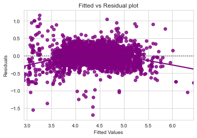

```python
# let us plot the fitted values vs residuals
sns.set_style("whitegrid")
sns.residplot(
    data=df_pred, x="Fitted Values", y="Residuals", color="purple", lowess=True
)
plt.xlabel("Fitted Values")
plt.ylabel("Residuals")
plt.title("Fitted vs Residual plot")
plt.show()
```

**Observations**

- I am not observing a pattern in the data, it looks randomly distributed

#### Normality

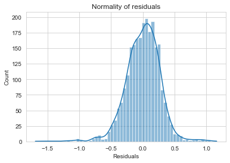

```python
sns.histplot(df_pred["Residuals"], kde=True)
plt.title("Normality of residuals")
plt.show()
```

**Observations**

- The residual terms look normally distributed

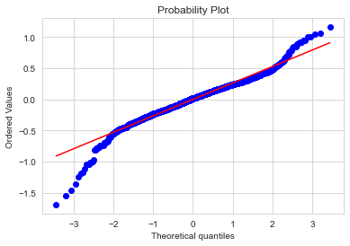

```python
import pylab
import scipy.stats as stats

stats.probplot(df_pred["Residuals"], dist="norm", plot=pylab)
plt.show()
```

**Observations**

- Most of the points are on the straight line of the QQ plot

#### Homoscedasticity

```python
import statsmodels.stats.api as sms
from statsmodels.compat import lzip

name = ["F statistic", "p-value"]
test = sms.het_goldfeldquandt(df_pred["Residuals"], x_train34)
lzip(name, test)
```

```
[('F statistic', 1.0533898326726359), ('p-value', 0.18473298393506601)]
```

**Observations**

- P-value is greater than 0.05 so we can say the residuals are homoscedastic

## Model performance evaluation

```python
print(olsres_34.summary())
```

```
                            OLS Regression Results
==============================================================================
Dep. Variable:         used_price_log   R-squared:                       0.788
Model:                            OLS   Adj. R-squared:                  0.787
Method:                 Least Squares   F-statistic:                     595.7
Date:                Fri, 04 Mar 2022   Prob (F-statistic):               0.00
Time:                        13:55:36   Log-Likelihood:                -252.49
No. Observations:                2417   AIC:                             537.0
Df Residuals:                    2401   BIC:                             629.6
Df Model:                          15
Covariance Type:            nonrobust
==========================================================================================
                             coef    std err          t      P>|t|      [0.025      0.975]
------------------------------------------------------------------------------------------
const                      2.8972      0.033     86.627      0.000       2.832       2.963
screen_size                0.0355      0.003     10.190      0.000       0.029       0.042
main_camera_mp             0.0314      0.002     19.959      0.000       0.028       0.034
selfie_camera_mp           0.0162      0.001     14.605      0.000       0.014       0.018
int_memory                 0.0004   7.93e-05      4.537      0.000       0.000       0.001
ram                        0.0514      0.005     10.211      0.000       0.041       0.061
weight                     0.0009      0.000      6.558      0.000       0.001       0.001
brand_name_Celkon         -0.2019      0.061     -3.312      0.001      -0.321      -0.082
brand_name_Micromax       -0.1563      0.031     -5.009      0.000      -0.217      -0.095
brand_name_Nokia           0.1061      0.035      2.998      0.003       0.037       0.175
brand_name_Spice          -0.1462      0.057     -2.548      0.011      -0.259      -0.034
os_Others                 -0.2238      0.034     -6.511      0.000      -0.291      -0.156
os_iOS                     0.1055      0.052      2.046      0.041       0.004       0.207
4g_yes                     0.1124      0.016      7.182      0.000       0.082       0.143
price_category_Mid         0.1977      0.014     14.236      0.000       0.170       0.225
price_category_Premium     0.4045      0.022     18.406      0.000       0.361       0.448
==============================================================================
Omnibus:                      264.407   Durbin-Watson:                   1.922
Prob(Omnibus):                  0.000   Jarque-Bera (JB):             1062.367
Skew:                          -0.477   Prob(JB):                    2.04e-231
Kurtosis:                       6.105   Cond. No.                     2.39e+03
==============================================================================

Warnings:
[1] Standard Errors assume that the covariance matrix of the errors is correctly specified.
[2] The condition number is large, 2.39e+03. This might indicate that there are
strong multicollinearity or other numerical problems.
```

```python
Equation = "used price ="
print(Equation, end=" ")
for i in range(len(x_train35.columns)):
    if i == 0:
        print(olsres_34.params[i], "+", end=" ")
    elif i != len(x_train35.columns) - 1:
        print(
            olsres_34.params[i],
            "* (",
            x_train35.columns[i],
            ")",
            "+",
            end="  ",
        )
    else:
        print(olsres_34.params[i], "* (", x_train35.columns[i], ")")
```

[output not shown]

## Final Model Summary

```python
# function to compute adjusted R-squared
def adj_r2_score(predictors, targets, predictions):
    r2 = r2_score(targets, predictions)
    n = predictors.shape[0]
    k = predictors.shape[1]
    return 1 - ((1 - r2) * (n - 1) / (n - k - 1))


# function to compute MAPE
def mape_score(targets, predictions):

    return np.mean(np.abs(targets - predictions) / targets) * 100


# function to compute different metrics to check performance of a regression model
def model_performance_regression(model, predictors, target):
    """
    Function to compute different metrics to check regression model performance

    model: regressor
    predictors: independent variables
    target: dependent variable
    """

    # predicting using the independent variables
    pred = model.predict(predictors)

    r2 = r2_score(target, pred)  # to compute R-squared
    adjr2 = adj_r2_score(predictors, target, pred)  # to compute adjusted R-squared
    rmse = np.sqrt(mean_squared_error(target, pred))  # to compute RMSE
    mae = mean_absolute_error(target, pred)  # to compute MAE
    mape = mape_score(target, pred)  # to compute MAPE

    # creating a dataframe of metrics
    df_perf = pd.DataFrame(
        {
            "RMSE": rmse,
            "MAE": mae,
            "R-squared": r2,
            "Adj. R-squared": adjr2,
            "MAPE": mape,
        },
        index=[0],
    )

    return df_perf
```

```python
# fitting a linear model
olsmodel = sm.OLS(y_train, x_train35).fit()
print(olsmodel.summary())
```

```
                            OLS Regression Results
==============================================================================
Dep. Variable:         used_price_log   R-squared:                       0.788
Model:                            OLS   Adj. R-squared:                  0.787
Method:                 Least Squares   F-statistic:                     595.7
Date:                Fri, 04 Mar 2022   Prob (F-statistic):               0.00
Time:                        13:55:52   Log-Likelihood:                -252.49
No. Observations:                2417   AIC:                             537.0
Df Residuals:                    2401   BIC:                             629.6
Df Model:                          15
Covariance Type:            nonrobust
==========================================================================================
                             coef    std err          t      P>|t|      [0.025      0.975]
------------------------------------------------------------------------------------------
const                      2.8972      0.033     86.627      0.000       2.832       2.963
screen_size                0.0355      0.003     10.190      0.000       0.029       0.042
main_camera_mp             0.0314      0.002     19.959      0.000       0.028       0.034
selfie_camera_mp           0.0162      0.001     14.605      0.000       0.014       0.018
int_memory                 0.0004   7.93e-05      4.537      0.000       0.000       0.001
ram                        0.0514      0.005     10.211      0.000       0.041       0.061
weight                     0.0009      0.000      6.558      0.000       0.001       0.001
brand_name_Celkon         -0.2019      0.061     -3.312      0.001      -0.321      -0.082
brand_name_Micromax       -0.1563      0.031     -5.009      0.000      -0.217      -0.095
brand_name_Nokia           0.1061      0.035      2.998      0.003       0.037       0.175
brand_name_Spice          -0.1462      0.057     -2.548      0.011      -0.259      -0.034
os_Others                 -0.2238      0.034     -6.511      0.000      -0.291      -0.156
os_iOS                     0.1055      0.052      2.046      0.041       0.004       0.207
4g_yes                     0.1124      0.016      7.182      0.000       0.082       0.143
price_category_Mid         0.1977      0.014     14.236      0.000       0.170       0.225
price_category_Premium     0.4045      0.022     18.406      0.000       0.361       0.448
==============================================================================
Omnibus:                      264.407   Durbin-Watson:                   1.922
Prob(Omnibus):                  0.000   Jarque-Bera (JB):             1062.367
Skew:                          -0.477   Prob(JB):                    2.04e-231
Kurtosis:                       6.105   Cond. No.                     2.39e+03
==============================================================================

Warnings:
[1] Standard Errors assume that the covariance matrix of the errors is correctly specified.
[2] The condition number is large, 2.39e+03. This might indicate that there are
strong multicollinearity or other numerical problems.
```

```python
print("Training Performance\n")
olsmodel_train_perf = model_performance_regression(olsmodel, x_train35, y_train)
olsmodel_train_perf
```

```
Training Performance
```

|  | RMSE | MAE | R-squared | Adj. R-squared | MAPE |
| --- | --- | --- | --- | --- | --- |
| 0 | 0.269 | 0.203 | 0.788 | 0.787 | 4.917 |

```python
# Remove columns from test data that we removed from training data
x_test2 = x_test1.drop(['battery','release_year','days_used','brand_name_Alcatel', 'brand_name_Apple', 'brand_name_Asus',
                       'brand_name_BlackBerry', 'brand_name_Coolpad', 'brand_name_Gionee', 'brand_name_Google', 'brand_name_HTC',
                       'brand_name_Honor', 'brand_name_Huawei', 'brand_name_Infinix', 'brand_name_Karbonn', 'brand_name_LG', 'brand_name_Lava', 'brand_name_Lenovo', 'brand_name_Meizu',
                       'brand_name_Microsoft', 'brand_name_Motorola', 'brand_name_OnePlus', 'brand_name_Oppo', 'brand_name_Others',
                       'brand_name_Panasonic', 'brand_name_Realme', 'brand_name_Samsung', 'brand_name_Sony', 'brand_name_Vivo', 'brand_name_XOLO', 'brand_name_Xiaomi', 'brand_name_ZTE',
                       'os_Windows', '5g_yes'], axis=1)
```

```python
print("Test Performance\n")
olsmodel_test_perf = model_performance_regression(olsmodel, x_test2, y_test)
olsmodel_test_perf
```

```
Test Performance
```

|  | RMSE | MAE | R-squared | Adj. R-squared | MAPE |
| --- | --- | --- | --- | --- | --- |
| 0 | 0.277 | 0.207 | 0.787 | 0.784 | 5.135 |

## Actionable Insights and Recommendations

**Observations**

- The train and test $R^2$ are 0.788 and 0.787, indicating that the model explains 78.8% and 78.7% of the total variation in the train and test sets respectively. Also, both scares are comparible
- RMSE values on the train and test sets are comparable
- These show that the model is not overfitting
- MAE indicates that our current model is able to predict used_device prices within a mean error of 0.2 on the test set
- MAPE of 5.135 on the test data means that we are able to predict within 5% of the used device price

**Recommendations**

- We use the variables:

  ```
   'const', 'screen_size', 'main_camera_mp', 'selfie_camera_mp',
   'int_memory', 'ram', 'weight', 'brand_name_Celkon',
   'brand_name_Micromax', 'brand_name_Nokia', 'brand_name_Spice',
   'os_Others', 'os_iOS', '4g_yes', 'price_category_Mid',
   'price_category_Premium'
  ```

- The other columns in the dataset are not important for building a model and can be removed
- Based on our model they can predict almost 79% of the used device price